# Titanic

Catherine Williams

May 7, 2019

##### *[Kaggle Competition](https://www.kaggle.com/c/titanic)*

# 1 Competition Description

The sinking of the RMS Titanic is one of the most infamous shipwrecks in history. On April 15, 1912, during her maiden voyage, the Titanic sank after colliding with an iceberg, killing 1502 out of 2224 passengers and crew. This sensational tragedy shocked the international community and led to better safety regulations for ships.

One of the reasons that the shipwreck led to such loss of life was that there were not enough lifeboats for the passengers and crew. Although there was some element of luck involved in surviving the sinking, some groups of people were more likely to survive than others, such as women, children, and the upper-class.

In this challenge, we ask you to complete the analysis of what sorts of people were likely to survive. In particular, we ask you to apply the tools of machine learning to predict which passengers survived the tragedy.

# 2 Dataset

Data came from Kaggle.com as a part of the online competition.

# 3 Setup

Load libraries

```r
knitr::opts_chunk$set(echo = TRUE)

library(tidyverse)
library(dplyr)
library(stringr) #strings
library(zoo) #na.aggregrate
library(modeest) #mode
library(ROCR) #ROC curve
library(caret)
library(class)
library(gmodels)
library(randomForest)
```

Import the data frames that Kaggle provided.

```r
#import data frames
path <- "C:/Users/Cat/Google Drive/Data Analysis/Kaggle Competitions/Titanic - Machine Learning/"

df_train <- read_csv(file=str_c(path, "train.csv"))
df_test <- read_csv(file=str_c(path, "test.csv"))
```

# 4 Data Manipulation

## 4.1 Review Data

Review training data to understand it.

Find missing values.

```r
#review data frame
df_train %>% glimpse()
```

```
## Observations: 891
## Variables: 12
## $ PassengerId <dbl> 1, 2, 3, 4, 5, 6, 7, 8, 9, 10, 11, 12, 13, 14, 15,...
## $ Survived    <dbl> 0, 1, 1, 1, 0, 0, 0, 0, 1, 1, 1, 1, 0, 0, 0, 1, 0,...
## $ Pclass      <dbl> 3, 1, 3, 1, 3, 3, 1, 3, 3, 2, 3, 1, 3, 3, 3, 2, 3,...
## $ Name        <chr> "Braund, Mr. Owen Harris", "Cumings, Mrs. John Bra...
## $ Sex         <chr> "male", "female", "female", "female", "male", "mal...
## $ Age         <dbl> 22, 38, 26, 35, 35, NA, 54, 2, 27, 14, 4, 58, 20, ...
## $ SibSp       <dbl> 1, 1, 0, 1, 0, 0, 0, 3, 0, 1, 1, 0, 0, 1, 0, 0, 4,...
## $ Parch       <dbl> 0, 0, 0, 0, 0, 0, 0, 1, 2, 0, 1, 0, 0, 5, 0, 0, 1,...
## $ Ticket      <chr> "A/5 21171", "PC 17599", "STON/O2. 3101282", "1138...
## $ Fare        <dbl> 7.2500, 71.2833, 7.9250, 53.1000, 8.0500, 8.4583, ...
## $ Cabin       <chr> NA, "C85", NA, "C123", NA, NA, "E46", NA, NA, NA, ...
## $ Embarked    <chr> "S", "C", "S", "S", "S", "Q", "S", "S", "S", "C", ...
```

```r
df_test %>% glimpse()
```

```
## Observations: 418
## Variables: 11
## $ PassengerId <dbl> 892, 893, 894, 895, 896, 897, 898, 899, 900, 901, ...
## $ Pclass      <dbl> 3, 3, 2, 3, 3, 3, 3, 2, 3, 3, 3, 1, 1, 2, 1, 2, 2,...
## $ Name        <chr> "Kelly, Mr. James", "Wilkes, Mrs. James (Ellen Nee...
## $ Sex         <chr> "male", "female", "male", "male", "female", "male"...
## $ Age         <dbl> 34.5, 47.0, 62.0, 27.0, 22.0, 14.0, 30.0, 26.0, 18...
## $ SibSp       <dbl> 0, 1, 0, 0, 1, 0, 0, 1, 0, 2, 0, 0, 1, 1, 1, 1, 0,...
## $ Parch       <dbl> 0, 0, 0, 0, 1, 0, 0, 1, 0, 0, 0, 0, 0, 0, 0, 0, 0,...
## $ Ticket      <chr> "330911", "363272", "240276", "315154", "3101298",...
## $ Fare        <dbl> 7.8292, 7.0000, 9.6875, 8.6625, 12.2875, 9.2250, 7...
## $ Cabin       <chr> NA, NA, NA, NA, NA, NA, NA, NA, NA, NA, NA, NA, "B...
## $ Embarked    <chr> "Q", "S", "Q", "S", "S", "S", "Q", "S", "C", "S", ...
```

```r
df_train$Survived %>% table()
```

```
## .
##   0   1
## 549 342
```

```r
sapply(df_train, function(x) sum(is.na(x)))
```

```
## PassengerId    Survived      Pclass        Name         Sex         Age
##           0           0           0           0           0         177
##       SibSp       Parch      Ticket        Fare       Cabin    Embarked
##           0           0           0           0         687           2
```

```r
sapply(df_train, function(x) length(unique(x)))
```

```
## PassengerId    Survived      Pclass        Name         Sex         Age
##         891           2           3         891           2          89
##       SibSp       Parch      Ticket        Fare       Cabin    Embarked
##           7           7         681         248         148           4
```

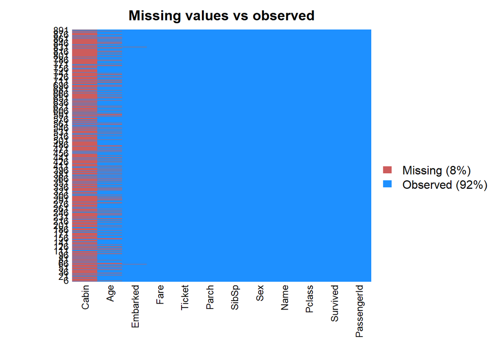

```r
Amelia::missmap(df_train, main = "Missing values vs observed")
```

Combine data for cleaning so that the same manipulations are applied to everything.

```r
#combine data for cleaning
df <- bind_rows(df_train, df_test)

df %>% glimpse()
```

```
## Observations: 1,309
## Variables: 12
## $ PassengerId <dbl> 1, 2, 3, 4, 5, 6, 7, 8, 9, 10, 11, 12, 13, 14, 15,...
## $ Survived    <dbl> 0, 1, 1, 1, 0, 0, 0, 0, 1, 1, 1, 1, 0, 0, 0, 1, 0,...
## $ Pclass      <dbl> 3, 1, 3, 1, 3, 3, 1, 3, 3, 2, 3, 1, 3, 3, 3, 2, 3,...
## $ Name        <chr> "Braund, Mr. Owen Harris", "Cumings, Mrs. John Bra...
## $ Sex         <chr> "male", "female", "female", "female", "male", "mal...
## $ Age         <dbl> 22, 38, 26, 35, 35, NA, 54, 2, 27, 14, 4, 58, 20, ...
## $ SibSp       <dbl> 1, 1, 0, 1, 0, 0, 0, 3, 0, 1, 1, 0, 0, 1, 0, 0, 4,...
## $ Parch       <dbl> 0, 0, 0, 0, 0, 0, 0, 1, 2, 0, 1, 0, 0, 5, 0, 0, 1,...
## $ Ticket      <chr> "A/5 21171", "PC 17599", "STON/O2. 3101282", "1138...
## $ Fare        <dbl> 7.2500, 71.2833, 7.9250, 53.1000, 8.0500, 8.4583, ...
## $ Cabin       <chr> NA, "C85", NA, "C123", NA, NA, "E46", NA, NA, NA, ...
## $ Embarked    <chr> "S", "C", "S", "S", "S", "Q", "S", "S", "S", "C", ...
```

## 4.2 Data Cleaning and Feature Engineering

Perform data cleaning:

```r
#clean data
df <- df %>% mutate_if(is.character, ~replace(., is.na(.), "NA"))

df <- df %>% mutate(PassengerId = as.integer(PassengerId),
                    Survived = as.logical(Survived),
                    Pclass = as.ordered(Pclass),
                    Title = str_extract(Name, "(?<=,\\s)[:alpha:]+\\s?[:alpha:]*(?=.)") %>% as.factor(),
                    Group = case_when(Title %in% c("Capt","Col","Major","Dr","Mr","Rev") ~ "Officer",
                                      Title %in% c("the Countess","Lady","Sir","Don","Dona","Jonkheer") ~ "Royalty",
                                      Title %in% c("Miss","Mlle","Ms") ~ "Miss",
                                      Title %in% c("Mme","Mrs") ~ "Mrs",
                                      Title == "Master" ~ "Master") %>% as.factor(),
                    Sex = as.factor(Sex),
                    Family = as.ordered(SibSp + Parch),
                    SibSp = as.ordered(SibSp),
                    ParCh = as.ordered(Parch),
                    Fare = na.aggregate(Fare,Pclass),
                    Cabin = as.factor(Cabin),
                    Embarked = replace(Embarked, is.na(Embarked), mfv(Embarked, na.rm=T)) %>% as.factor()) %>%
  select(-Name,-Parch,-Ticket)


sapply(df, function(x) sum(is.na(x)))
```

```
## PassengerId    Survived      Pclass         Sex         Age       SibSp
##           0         418           0           0         263           0
##        Fare       Cabin    Embarked       Title       Group      Family
##           0           0           0           0           0           0
##       ParCh
##           0
```

```r
df %>% glimpse()
```

```
## Observations: 1,309
## Variables: 13
## $ PassengerId <int> 1, 2, 3, 4, 5, 6, 7, 8, 9, 10, 11, 12, 13, 14, 15,...
## $ Survived    <lgl> FALSE, TRUE, TRUE, TRUE, FALSE, FALSE, FALSE, FALS...
## $ Pclass      <ord> 3, 1, 3, 1, 3, 3, 1, 3, 3, 2, 3, 1, 3, 3, 3, 2, 3,...
## $ Sex         <fct> male, female, female, female, male, male, male, ma...
## $ Age         <dbl> 22, 38, 26, 35, 35, NA, 54, 2, 27, 14, 4, 58, 20, ...
## $ SibSp       <ord> 1, 1, 0, 1, 0, 0, 0, 3, 0, 1, 1, 0, 0, 1, 0, 0, 4,...
## $ Fare        <dbl> 7.2500, 71.2833, 7.9250, 53.1000, 8.0500, 8.4583, ...
## $ Cabin       <fct> NA, C85, NA, C123, NA, NA, E46, NA, NA, NA, G6, C1...
## $ Embarked    <fct> S, C, S, S, S, Q, S, S, S, C, S, S, S, S, S, S, Q,...
## $ Title       <fct> Mr, Mrs, Miss, Mrs, Mr, Mr, Mr, Master, Mrs, Mrs, ...
## $ Group       <fct> Officer, Mrs, Miss, Mrs, Officer, Officer, Officer...
## $ Family      <ord> 1, 1, 0, 1, 0, 0, 0, 4, 2, 1, 2, 0, 0, 6, 0, 0, 5,...
## $ ParCh       <ord> 0, 0, 0, 0, 0, 0, 0, 1, 2, 0, 1, 0, 0, 5, 0, 0, 1,...
```

Determine which features can predict age in order to provide better estimates for missing values.

```r
##create a model to see which features can estimate age
age1 <- lm(Age ~ Pclass+Group, data=df)

age1 %>% summary()
```

```
##
## Call:
## lm(formula = Age ~ Pclass + Group, data = df)
##
## Residuals:
##     Min      1Q  Median      3Q     Max
## -28.137  -7.866  -0.866   6.477  45.134
##
## Coefficients:
##              Estimate Std. Error t value Pr(>|t|)
## (Intercept)    8.9721     1.5535   5.776 1.01e-08 ***
## Pclass.L      -9.0298     0.6006 -15.035  < 2e-16 ***
## Pclass.Q       2.3736     0.6589   3.603  0.00033 ***
## GroupMiss     13.8110     1.7196   8.032 2.59e-15 ***
## GroupMrs      27.1856     1.7786  15.285  < 2e-16 ***
## GroupOfficer  25.3102     1.6029  15.790  < 2e-16 ***
## GroupRoyalty  24.8406     4.8556   5.116 3.72e-07 ***
## ---
## Signif. codes:  0 '***' 0.001 '**' 0.01 '*' 0.05 '.' 0.1 ' ' 1
##
## Residual standard error: 11.15 on 1039 degrees of freedom
##   (263 observations deleted due to missingness)
## Multiple R-squared:  0.4053, Adjusted R-squared:  0.4019
## F-statistic:   118 on 6 and 1039 DF,  p-value: < 2.2e-16
```

```r
age1 %>% anova(test="Chisq")
```

```
## Analysis of Variance Table
##
## Response: Age
##             Df Sum Sq Mean Sq F value    Pr(>F)
## Pclass       2  37339 18669.7  150.26 < 2.2e-16 ***
## Group        4  50660 12664.9  101.93 < 2.2e-16 ***
## Residuals 1039 129098   124.3
## ---
## Signif. codes:  0 '***' 0.001 '**' 0.01 '*' 0.05 '.' 0.1 ' ' 1
```

```r
df %>% group_by(Pclass,Group) %>% summarize(Age = Age %>% mean(na.rm=TRUE))
```

```
## # A tibble: 13 x 3
## # Groups:   Pclass [3]
##    Pclass Group     Age
##    <ord>  <fct>   <dbl>
##  1 1      Master   6.98
##  2 1      Miss    30.1
##  3 1      Mrs     42.9
##  4 1      Officer 42.2
##  5 1      Royalty 41.2
##  6 2      Master   2.76
##  7 2      Miss    20.9
##  8 2      Mrs     33.5
##  9 2      Officer 32.9
## 10 3      Master   6.09
## 11 3      Miss    17.4
## 12 3      Mrs     32.3
## 13 3      Officer 28.3
```

Add in missing values for Age using mean, grouped by Pclass and Group.

Create a more general feature for Child.

```r
#estimate age and create child feature
df <- df %>% mutate(Age = na.aggregate(Age,c(Pclass,Group)),
                    Child = case_when(Age < 18 ~ 1,
                            Age >= 18 ~ 0) %>% as.logical())
sapply(df, function(x) sum(is.na(x)))
```

```
## PassengerId    Survived      Pclass         Sex         Age       SibSp
##           0         418           0           0           0           0
##        Fare       Cabin    Embarked       Title       Group      Family
##           0           0           0           0           0           0
##       ParCh       Child
##           0           0
```

Perform more manipulations on Cabin to figure out if the letter or number has any significance.

```r
#df_cabin
df_cabin <- str_split(df$Cabin, " ")

df_cabin <- data.frame(PassengerId = rep(df$PassengerId, sapply(df_cabin, length)),
                       Cabin = unlist(df_cabin))


df_cabin <- df_cabin %>% mutate(CabinLtr = str_extract(Cabin, "^[:alpha:]*"),
                                CabinLtr = as.factor(CabinLtr)) %>%
  select(PassengerId, CabinLtr)

df_cabin %>% glimpse() %>% summary()
```

```
## Observations: 1,370
## Variables: 2
## $ PassengerId <int> 1, 2, 3, 4, 5, 6, 7, 8, 9, 10, 11, 12, 13, 14, 15,...
## $ CabinLtr    <fct> NA, C, NA, C, NA, NA, E, NA, NA, NA, G, C, NA, NA,...
```

```
##   PassengerId        CabinLtr
##  Min.   :   1.0   NA     :1014
##  1st Qu.: 329.2   C      : 114
##  Median : 664.5   B      :  96
##  Mean   : 657.9   D      :  48
##  3rd Qu.: 981.8   E      :  45
##  Max.   :1309.0   A      :  22
##                   (Other):  31
```

Put Cabin dataframe back into main dataframe.

```r
#join dataframes back together
df <- df %>% inner_join(df_cabin, by="PassengerId") %>% select(-Cabin)

df %>% glimpse()
```

```
## Observations: 1,370
## Variables: 14
## $ PassengerId <int> 1, 2, 3, 4, 5, 6, 7, 8, 9, 10, 11, 12, 13, 14, 15,...
## $ Survived    <lgl> FALSE, TRUE, TRUE, TRUE, FALSE, FALSE, FALSE, FALS...
## $ Pclass      <ord> 3, 1, 3, 1, 3, 3, 1, 3, 3, 2, 3, 1, 3, 3, 3, 2, 3,...
## $ Sex         <fct> male, female, female, female, male, male, male, ma...
## $ Age         <dbl> 22.00000, 38.00000, 26.00000, 35.00000, 35.00000, ...
## $ SibSp       <ord> 1, 1, 0, 1, 0, 0, 0, 3, 0, 1, 1, 0, 0, 1, 0, 0, 4,...
## $ Fare        <dbl> 7.2500, 71.2833, 7.9250, 53.1000, 8.0500, 8.4583, ...
## $ Embarked    <fct> S, C, S, S, S, Q, S, S, S, C, S, S, S, S, S, S, Q,...
## $ Title       <fct> Mr, Mrs, Miss, Mrs, Mr, Mr, Mr, Master, Mrs, Mrs, ...
## $ Group       <fct> Officer, Mrs, Miss, Mrs, Officer, Officer, Officer...
## $ Family      <ord> 1, 1, 0, 1, 0, 0, 0, 4, 2, 1, 2, 0, 0, 6, 0, 0, 5,...
## $ ParCh       <ord> 0, 0, 0, 0, 0, 0, 0, 1, 2, 0, 1, 0, 0, 5, 0, 0, 1,...
## $ Child       <lgl> FALSE, FALSE, FALSE, FALSE, FALSE, FALSE, FALSE, T...
## $ CabinLtr    <fct> NA, C, NA, C, NA, NA, E, NA, NA, NA, G, C, NA, NA,...
```

Remove any duplicate rows that could skew the model.

```r
# Remove duplicate rows
df <- df %>% distinct()
```

# 5 Evaluate Trends

Create variables to use in plots in order to evaluate potential trends in the data.

```r
#create variables to use in functions
y_col <- "Survived"
x_cols <- df %>% names()
x_cols <- x_cols[!str_detect(x_cols, y_col)]
```

## 5.1 Numerical Features

Use boxplots to look for trends with numerical features.

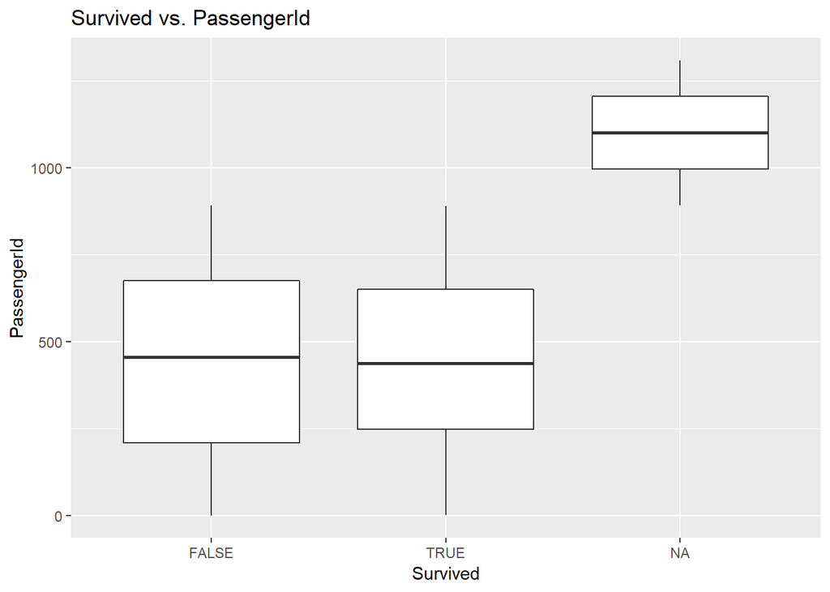

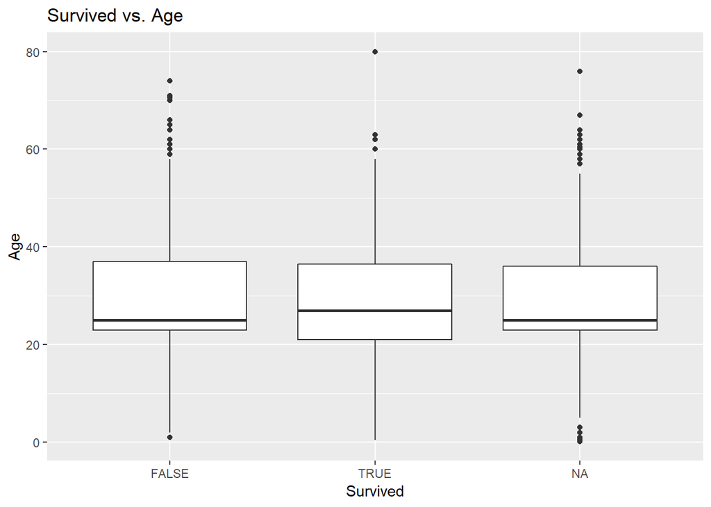

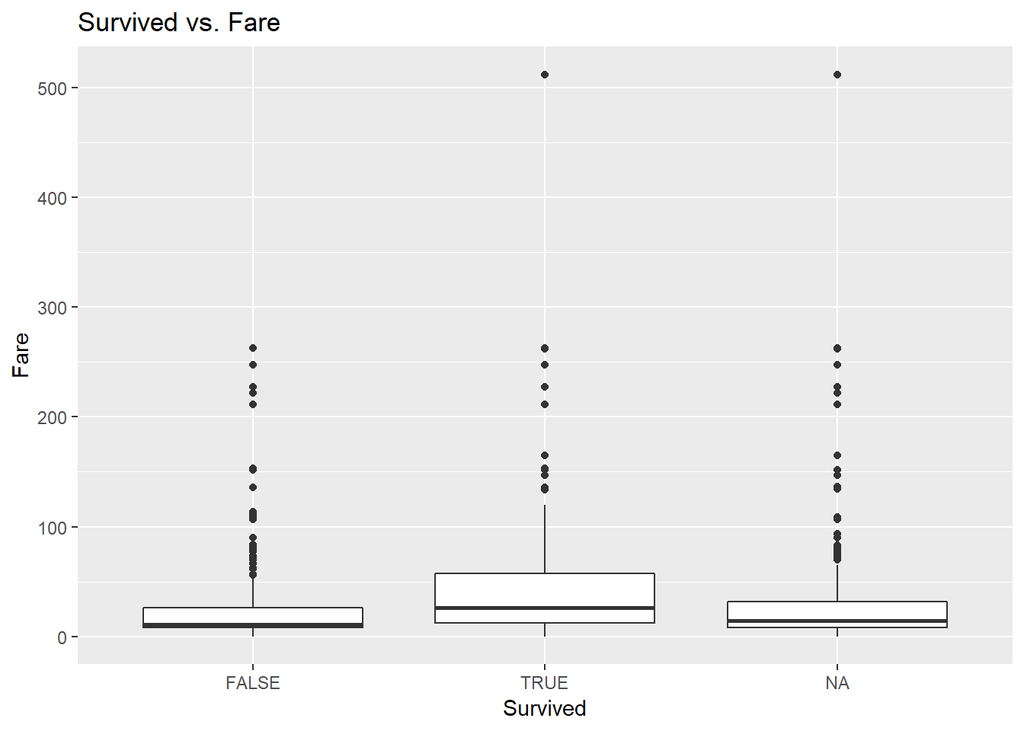

```r
#look for basic trends (boxplot)
gg_boxplot <- function(x_col, data){
  if(is.numeric(data[[x_col]])){
  plt <- data %>%
    ggplot(aes_string(x='Survived', y=x_col)) +
    geom_boxplot()+
    labs(title=str_c("Survived vs. ", x_col))

  plt %>% print()
  }
}

x_cols %>% walk(gg_boxplot, df)
```

## 5.2 Categorical Features

There are noticeable trends with Pclass, Sex, SibSp, Embarked, Title, Group, Family, ParCh, and Child.

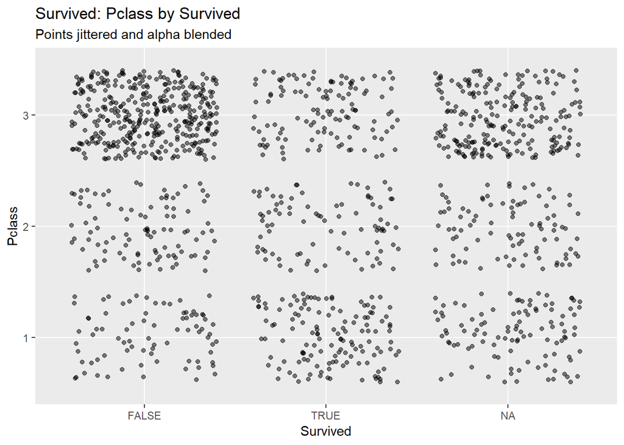

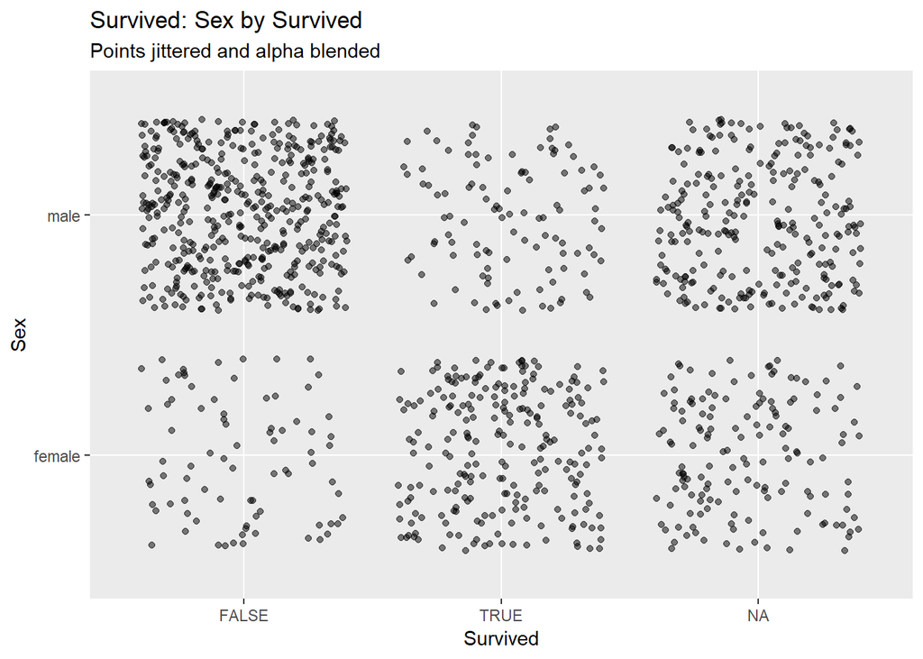

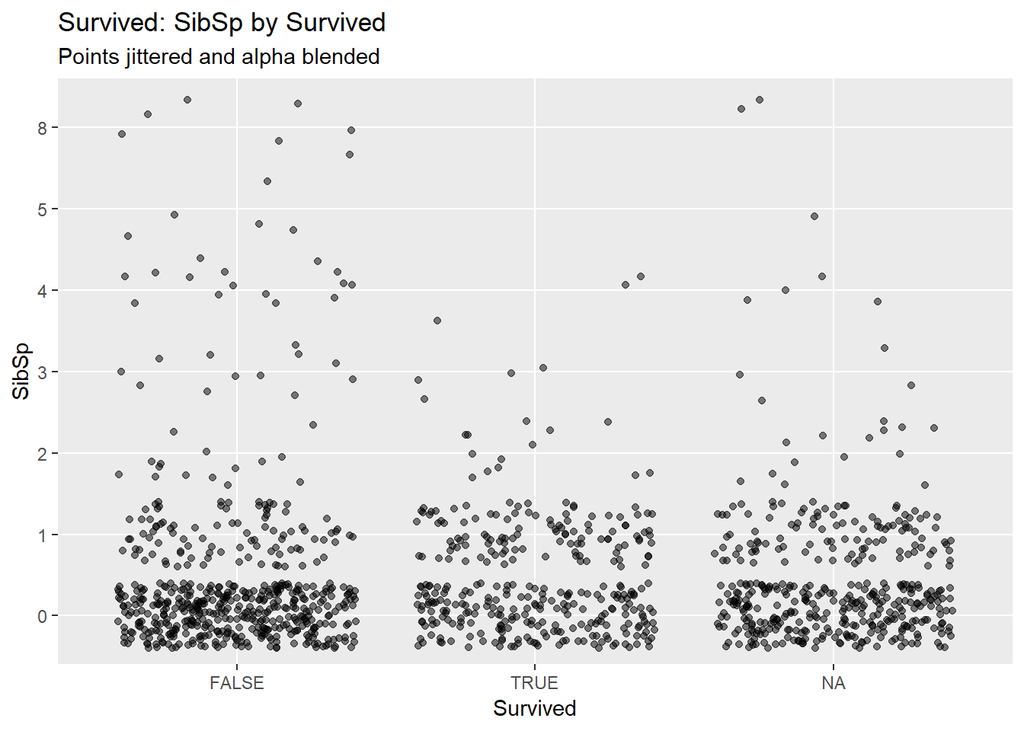

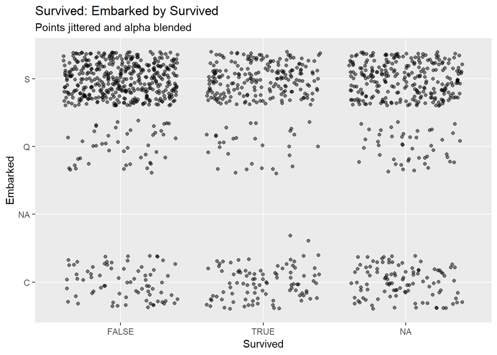

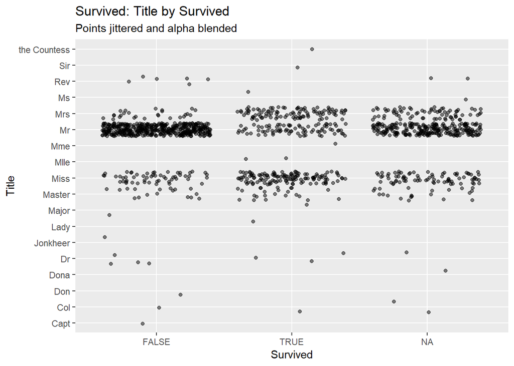

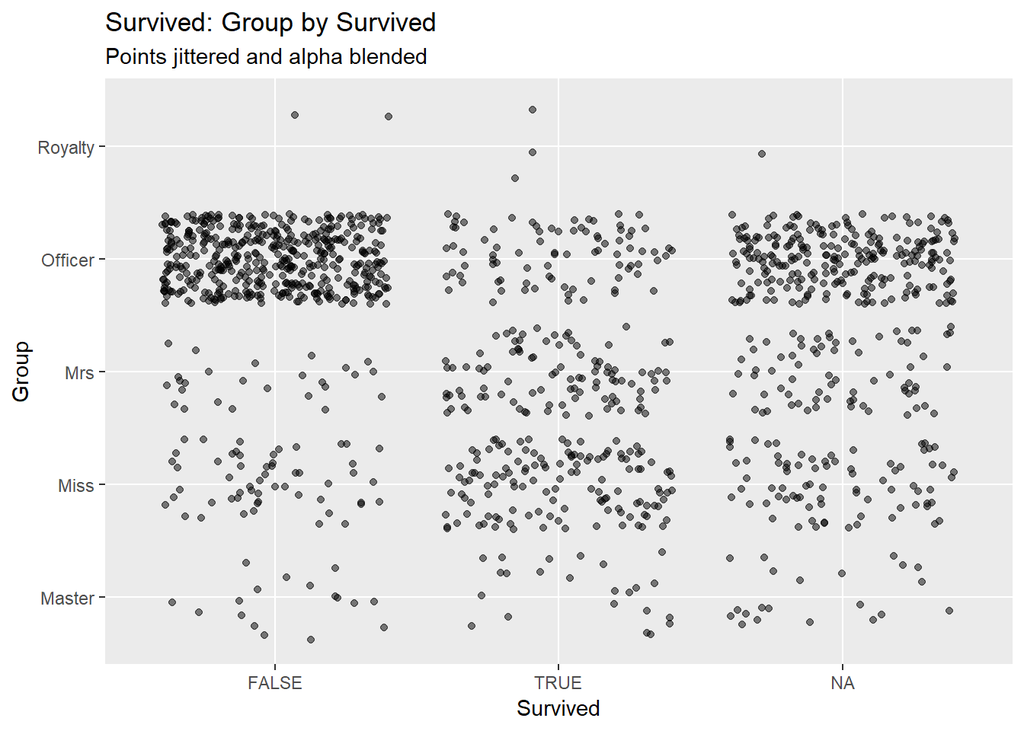

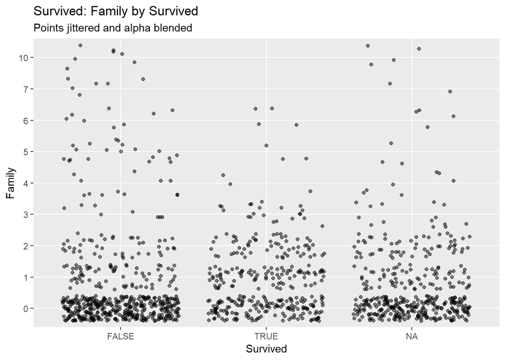

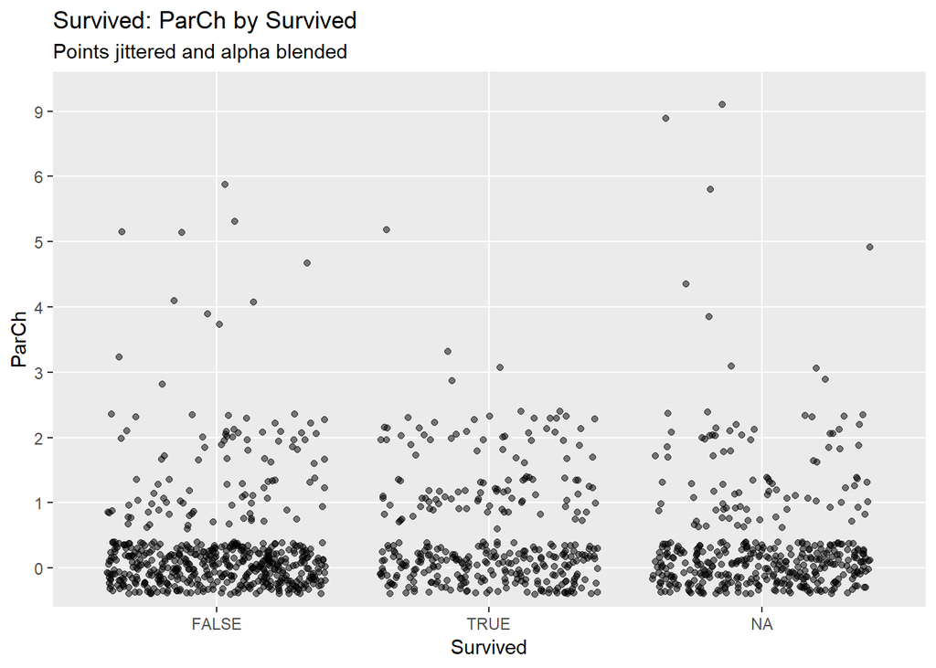

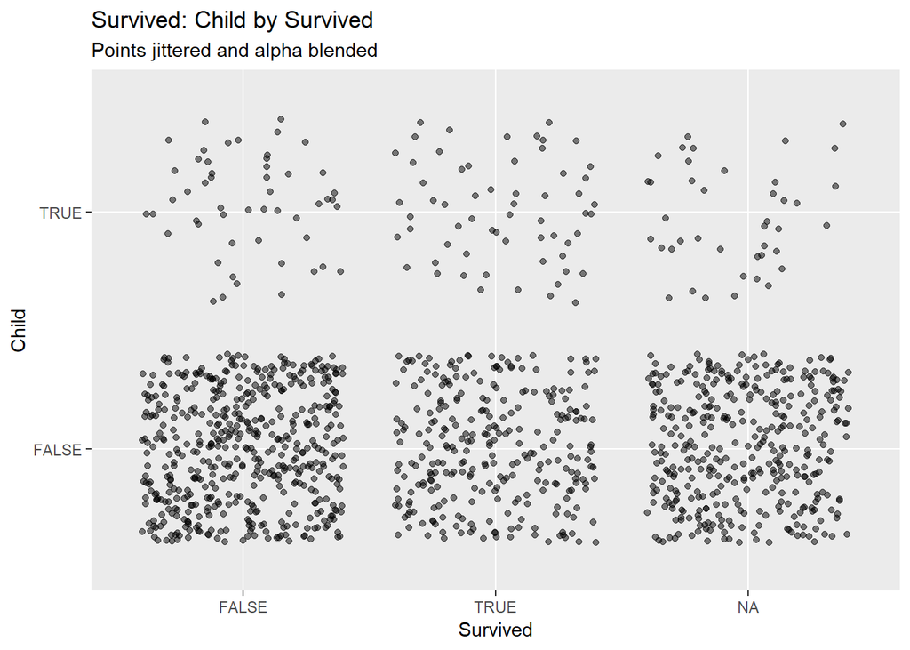

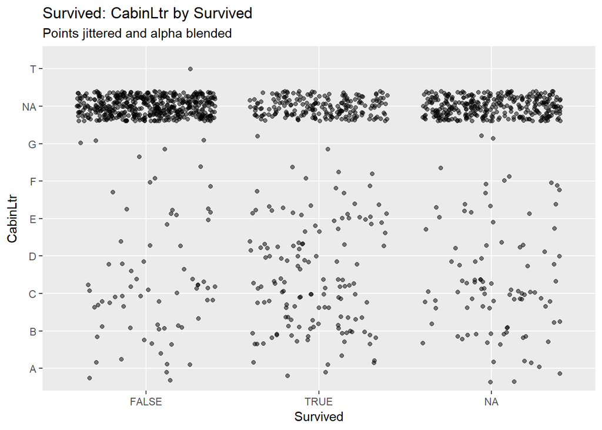

```r
#look for basic trends (scatter plot)
gg_scatter <- function(data, x_col, y_col) {
  if(!is.numeric(data[[x_col]])){
    plt <- data %>% ggplot(mapping=aes_string(x_col, y_col))+
      geom_jitter(alpha=0.5)+
      coord_flip()+
      labs(title=str_c("Survived: ", x_col, " by ", y_col), subtitle="Points jittered and alpha blended")
    plt %>% print()
  }
}

x_cols %>% walk(gg_scatter, data=df, y_col=y_col)
```

# 6 Prepare Data for Models

## 6.1 Normalize Data

Normalize the data frame so that model is not skewed by different types of measurements.

```r
#normalize dataframes
normalize <- function(x)(x - mean(x, na.rm=T))/sd(x, na.rm=T)

df_norm <- df %>% mutate_if(is.double, normalize)

df_norm %>% glimpse()
```

```
## Observations: 1,316
## Variables: 14
## $ PassengerId <int> 1, 2, 3, 4, 5, 6, 7, 8, 9, 10, 11, 12, 13, 14, 15,...
## $ Survived    <lgl> FALSE, TRUE, TRUE, TRUE, FALSE, FALSE, FALSE, FALS...
## $ Pclass      <ord> 3, 1, 3, 1, 3, 3, 1, 3, 3, 2, 3, 1, 3, 3, 3, 2, 3,...
## $ Sex         <fct> male, female, female, female, male, male, male, ma...
## $ Age         <dbl> -0.55963667, 0.66141600, -0.25437350, 0.43246862, ...
## $ SibSp       <ord> 1, 1, 0, 1, 0, 0, 0, 3, 0, 1, 1, 0, 0, 1, 0, 0, 4,...
## $ Fare        <dbl> -0.50169283, 0.73844524, -0.48862006, 0.38628780, ...
## $ Embarked    <fct> S, C, S, S, S, Q, S, S, S, C, S, S, S, S, S, S, Q,...
## $ Title       <fct> Mr, Mrs, Miss, Mrs, Mr, Mr, Mr, Master, Mrs, Mrs, ...
## $ Group       <fct> Officer, Mrs, Miss, Mrs, Officer, Officer, Officer...
## $ Family      <ord> 1, 1, 0, 1, 0, 0, 0, 4, 2, 1, 2, 0, 0, 6, 0, 0, 5,...
## $ ParCh       <ord> 0, 0, 0, 0, 0, 0, 0, 1, 2, 0, 1, 0, 0, 5, 0, 0, 1,...
## $ Child       <lgl> FALSE, FALSE, FALSE, FALSE, FALSE, FALSE, FALSE, T...
## $ CabinLtr    <fct> NA, C, NA, C, NA, NA, E, NA, NA, NA, G, C, NA, NA,...
```

## 6.2 Testing and Training Sets

Recreate original testing dataframe as well as a training and validation set.

```r
#break training set into training, validation and test sets
df_test_norm <- df_norm %>% filter(is.na(Survived))

set.seed(123)

df_train_norm <- df_norm %>% filter(!is.na(Survived)) %>% sample_frac(0.8)
df_val_norm <- df_norm %>% filter(!is.na(Survived)) %>% setdiff(df_train_norm)

df_test_norm %>% glimpse()
```

```
## Observations: 421
## Variables: 14
## $ PassengerId <int> 892, 893, 894, 895, 896, 897, 898, 899, 900, 901, ...
## $ Survived    <lgl> NA, NA, NA, NA, NA, NA, NA, NA, NA, NA, NA, NA, NA...
## $ Pclass      <ord> 3, 3, 2, 3, 3, 3, 3, 2, 3, 3, 3, 1, 1, 2, 1, 2, 2,...
## $ Sex         <fct> male, female, male, male, female, male, female, ma...
## $ Age         <dbl> 0.39431073, 1.34825812, 2.49299500, -0.17805771, -...
## $ SibSp       <ord> 0, 1, 0, 0, 1, 0, 0, 1, 0, 2, 0, 0, 1, 1, 1, 1, 0,...
## $ Fare        <dbl> -0.49047542, -0.50653461, -0.45448558, -0.47433683...
## $ Embarked    <fct> Q, S, Q, S, S, S, Q, S, C, S, S, S, S, S, S, C, Q,...
## $ Title       <fct> Mr, Mrs, Mr, Mr, Mrs, Mr, Miss, Mr, Mrs, Mr, Mr, M...
## $ Group       <fct> Officer, Mrs, Officer, Officer, Mrs, Officer, Miss...
## $ Family      <ord> 0, 1, 0, 0, 2, 0, 0, 2, 0, 2, 0, 0, 1, 1, 1, 1, 0,...
## $ ParCh       <ord> 0, 0, 0, 0, 1, 0, 0, 1, 0, 0, 0, 0, 0, 0, 0, 0, 0,...
## $ Child       <lgl> FALSE, FALSE, FALSE, FALSE, FALSE, TRUE, FALSE, FA...
## $ CabinLtr    <fct> NA, NA, NA, NA, NA, NA, NA, NA, NA, NA, NA, NA, B,...
```

```r
df_train_norm %>% glimpse()
```

```
## Observations: 716
## Variables: 14
## $ PassengerId <int> 256, 702, 364, 784, 834, 41, 468, 789, 488, 403, 8...
## $ Survived    <lgl> TRUE, TRUE, FALSE, FALSE, FALSE, FALSE, FALSE, TRU...
## $ Pclass      <ord> 3, 1, 3, 3, 3, 3, 1, 3, 1, 3, 1, 2, 2, 3, 3, 3, 3,...
## $ Sex         <fct> female, male, male, male, male, female, male, male...
## $ Age         <dbl> -0.02542613, 0.43246862, 0.43246862, -0.34470337, ...
## $ SibSp       <ord> 0, 0, 0, 1, 0, 1, 0, 1, 0, 1, 0, 0, 0, 0, 0, 4, 1,...
## $ Fare        <dbl> -0.346837533, -0.132992041, -0.505566251, -0.18794...
## $ Embarked    <fct> C, S, S, S, S, S, S, S, C, S, C, S, S, S, S, Q, Q,...
## $ Title       <fct> Mrs, Mr, Mr, Mr, Mr, Mrs, Mr, Master, Mr, Miss, Mi...
## $ Group       <fct> Mrs, Officer, Officer, Officer, Officer, Mrs, Offi...
## $ Family      <ord> 2, 0, 0, 3, 0, 1, 0, 3, 0, 1, 0, 0, 0, 0, 0, 5, 1,...
## $ ParCh       <ord> 2, 0, 0, 2, 0, 0, 0, 2, 0, 0, 0, 0, 0, 0, 0, 1, 0,...
## $ Child       <lgl> FALSE, FALSE, FALSE, FALSE, FALSE, FALSE, FALSE, T...
## $ CabinLtr    <fct> NA, E, NA, NA, NA, NA, NA, NA, B, NA, NA, NA, NA, ...
```

```r
df_val_norm %>% glimpse()
```

```
## Observations: 179
## Variables: 14
## $ PassengerId <int> 2, 3, 11, 17, 21, 25, 30, 31, 38, 42, 52, 54, 56, ...
## $ Survived    <lgl> TRUE, TRUE, TRUE, FALSE, FALSE, FALSE, FALSE, FALS...
## $ Pclass      <ord> 1, 3, 3, 3, 2, 3, 3, 1, 3, 2, 3, 2, 1, 2, 1, 3, 2,...
## $ Sex         <fct> female, female, female, male, male, female, male, ...
## $ Age         <dbl> 0.66141600, -0.25437350, -1.93332092, -2.08595250,...
## $ SibSp       <ord> 1, 0, 1, 4, 0, 3, 0, 0, 0, 1, 0, 1, 0, 0, 0, 4, 0,...
## $ Fare        <dbl> 0.73844524, -0.48862006, -0.31867392, -0.07803795,...
## $ Embarked    <fct> C, S, S, Q, S, S, S, C, S, S, S, S, S, S, C, S, S,...
## $ Title       <fct> Mrs, Miss, Miss, Master, Mr, Miss, Mr, Don, Mr, Mr...
## $ Group       <fct> Mrs, Miss, Miss, Master, Officer, Miss, Officer, R...
## $ Family      <ord> 1, 0, 2, 5, 0, 4, 0, 0, 0, 1, 0, 1, 0, 0, 0, 6, 0,...
## $ ParCh       <ord> 0, 0, 1, 1, 0, 1, 0, 0, 0, 0, 0, 0, 0, 0, 0, 2, 0,...
## $ Child       <lgl> FALSE, FALSE, TRUE, TRUE, FALSE, TRUE, FALSE, FALS...
## $ CabinLtr    <fct> C, NA, G, NA, NA, NA, NA, NA, NA, NA, NA, NA, C, N...
```

# 7 Models

## 7.1 Logistic Regression

Time to build some models.

The models below are statistically significant. They do not show the process of elimating features that were not statistically significant for determining the label.

The best model will be determined later.

```r
#build statistical models

#mod1
mod1 <- glm(Survived ~ Group+Pclass+Embarked, family=binomial(), data=df_train_norm)

mod1 %>% summary()
```

```
##
## Call:
## glm(formula = Survived ~ Group + Pclass + Embarked, family = binomial(),
##     data = df_train_norm)
##
## Deviance Residuals:
##     Min       1Q   Median       3Q      Max
## -2.3339  -0.6269  -0.3609   0.5805   2.3511
##
## Coefficients:
##               Estimate Std. Error z value Pr(>|z|)
## (Intercept)    1.39029    0.44247   3.142  0.00168 **
## GroupMiss      0.20742    0.42454   0.489  0.62514
## GroupMrs       0.82312    0.46665   1.764  0.07775 .
## GroupOfficer  -2.39966    0.41197  -5.825 5.72e-09 ***
## GroupRoyalty  -1.00648    1.24515  -0.808  0.41891
## Pclass.L      -1.50732    0.18999  -7.933 2.13e-15 ***
## Pclass.Q      -0.08629    0.20371  -0.424  0.67184
## EmbarkedNA    11.65444  617.33076   0.019  0.98494
## EmbarkedQ      0.17578    0.40312   0.436  0.66281
## EmbarkedS     -0.58830    0.26137  -2.251  0.02440 *
## ---
## Signif. codes:  0 '***' 0.001 '**' 0.01 '*' 0.05 '.' 0.1 ' ' 1
##
## (Dispersion parameter for binomial family taken to be 1)
##
##     Null deviance: 953.75  on 715  degrees of freedom
## Residual deviance: 625.83  on 706  degrees of freedom
## AIC: 645.83
##
## Number of Fisher Scoring iterations: 13
```

```r
anova(mod1, test="Chisq")
```

```
## Analysis of Deviance Table
##
## Model: binomial, link: logit
##
## Response: Survived
##
## Terms added sequentially (first to last)
##
##
##          Df Deviance Resid. Df Resid. Dev Pr(>Chi)
## NULL                       715     953.75
## Group     4  238.277       711     715.47  < 2e-16 ***
## Pclass    2   80.704       709     634.77  < 2e-16 ***
## Embarked  3    8.939       706     625.83  0.03012 *
## ---
## Signif. codes:  0 '***' 0.001 '**' 0.01 '*' 0.05 '.' 0.1 ' ' 1
```

```r
#mod2
mod2 <- glm(Survived ~ Pclass+Age+Group -1, family=binomial(), data=df_train_norm)

mod2 %>% summary()
```

```
##
## Call:
## glm(formula = Survived ~ Pclass + Age + Group - 1, family = binomial(),
##     data = df_train_norm)
##
## Deviance Residuals:
##     Min       1Q   Median       3Q      Max
## -2.5581  -0.6440  -0.4078   0.5945   2.3992
##
## Coefficients:
##              Estimate Std. Error z value Pr(>|z|)
## Pclass1        1.8267     0.4556   4.009 6.09e-05 ***
## Pclass2        0.5329     0.4711   1.131   0.2580
## Pclass3       -0.5648     0.4445  -1.271   0.2038
## Age           -0.2518     0.1282  -1.964   0.0495 *
## GroupMiss      0.5892     0.4466   1.320   0.1870
## GroupMrs       1.3232     0.5320   2.487   0.0129 *
## GroupOfficer  -1.9543     0.4636  -4.215 2.50e-05 ***
## GroupRoyalty  -0.4804     1.2593  -0.382   0.7028
## ---
## Signif. codes:  0 '***' 0.001 '**' 0.01 '*' 0.05 '.' 0.1 ' ' 1
##
## (Dispersion parameter for binomial family taken to be 1)
##
##     Null deviance: 992.59  on 716  degrees of freedom
## Residual deviance: 630.79  on 708  degrees of freedom
## AIC: 646.79
##
## Number of Fisher Scoring iterations: 5
```

```r
anova(mod2, test="Chisq")
```

```
## Analysis of Deviance Table
##
## Model: binomial, link: logit
##
## Response: Survived
##
## Terms added sequentially (first to last)
##
##
##        Df Deviance Resid. Df Resid. Dev  Pr(>Chi)
## NULL                     716     992.59
## Pclass  3  125.011       713     867.58 < 2.2e-16 ***
## Age     1   23.638       712     843.94 1.162e-06 ***
## Group   4  213.146       708     630.79 < 2.2e-16 ***
## ---
## Signif. codes:  0 '***' 0.001 '**' 0.01 '*' 0.05 '.' 0.1 ' ' 1
```

```r
#mod3
mod3 <- glm(Survived ~ Pclass+Sex+Age, family=binomial(), data=df_train_norm)

mod3 %>% summary()
```

```
##
## Call:
## glm(formula = Survived ~ Pclass + Sex + Age, family = binomial(),
##     data = df_train_norm)
##
## Deviance Residuals:
##     Min       1Q   Median       3Q      Max
## -2.6659  -0.6460  -0.4510   0.6444   2.4025
##
## Coefficients:
##             Estimate Std. Error z value Pr(>|z|)
## (Intercept)   1.4526     0.1699   8.551  < 2e-16 ***
## Pclass.L     -1.7074     0.1985  -8.603  < 2e-16 ***
## Pclass.Q      0.0245     0.1910   0.128 0.897927
## Sexmale      -2.5939     0.2080 -12.472  < 2e-16 ***
## Age          -0.4097     0.1114  -3.679 0.000235 ***
## ---
## Signif. codes:  0 '***' 0.001 '**' 0.01 '*' 0.05 '.' 0.1 ' ' 1
##
## (Dispersion parameter for binomial family taken to be 1)
##
##     Null deviance: 953.75  on 715  degrees of freedom
## Residual deviance: 652.93  on 711  degrees of freedom
## AIC: 662.93
##
## Number of Fisher Scoring iterations: 4
```

```r
anova(mod3, test="Chisq")
```

```
## Analysis of Deviance Table
##
## Model: binomial, link: logit
##
## Response: Survived
##
## Terms added sequentially (first to last)
##
##
##        Df Deviance Resid. Df Resid. Dev  Pr(>Chi)
## NULL                     715     953.75
## Pclass  2   86.172       713     867.58 < 2.2e-16 ***
## Sex     1  200.334       712     667.24 < 2.2e-16 ***
## Age     1   14.313       711     652.93 0.0001548 ***
## ---
## Signif. codes:  0 '***' 0.001 '**' 0.01 '*' 0.05 '.' 0.1 ' ' 1
```

```r
#mod4
mod4 <- glm(Survived ~ Pclass+Age+Embarked+Group, family=binomial(), data=df_train_norm)

mod4 %>% summary()
```

```
##
## Call:
## glm(formula = Survived ~ Pclass + Age + Embarked + Group, family = binomial(),
##     data = df_train_norm)
##
## Deviance Residuals:
##     Min       1Q   Median       3Q      Max
## -2.4914  -0.6379  -0.3715   0.6044   2.4851
##
## Coefficients:
##               Estimate Std. Error z value Pr(>|z|)
## (Intercept)    1.00441    0.48544   2.069   0.0385 *
## Pclass.L      -1.70017    0.21616  -7.865 3.68e-15 ***
## Pclass.Q      -0.04169    0.20637  -0.202   0.8399
## Age           -0.26122    0.12938  -2.019   0.0435 *
## EmbarkedNA    11.89108  621.42681   0.019   0.9847
## EmbarkedQ      0.27161    0.40551   0.670   0.5030
## EmbarkedS     -0.55441    0.26381  -2.102   0.0356 *
## GroupMiss      0.47689    0.45112   1.057   0.2905
## GroupMrs       1.33616    0.53828   2.482   0.0131 *
## GroupOfficer  -1.95975    0.46753  -4.192 2.77e-05 ***
## GroupRoyalty  -0.55550    1.26100  -0.441   0.6596
## ---
## Signif. codes:  0 '***' 0.001 '**' 0.01 '*' 0.05 '.' 0.1 ' ' 1
##
## (Dispersion parameter for binomial family taken to be 1)
##
##     Null deviance: 953.75  on 715  degrees of freedom
## Residual deviance: 621.63  on 705  degrees of freedom
## AIC: 643.63
##
## Number of Fisher Scoring iterations: 13
```

```r
anova(mod4, test="Chisq")
```

```
## Analysis of Deviance Table
##
## Model: binomial, link: logit
##
## Response: Survived
##
## Terms added sequentially (first to last)
##
##
##          Df Deviance Resid. Df Resid. Dev  Pr(>Chi)
## NULL                       715     953.75
## Pclass    2   86.172       713     867.58 < 2.2e-16 ***
## Age       1   23.638       712     843.94 1.162e-06 ***
## Embarked  3   20.828       709     823.11 0.0001143 ***
## Group     4  201.484       705     621.63 < 2.2e-16 ***
## ---
## Signif. codes:  0 '***' 0.001 '**' 0.01 '*' 0.05 '.' 0.1 ' ' 1
```

View models side by side to compare them to each other.

```r
mod1 %>% broom::glance()
```

```
## # A tibble: 1 x 7
##   null.deviance df.null logLik   AIC   BIC deviance df.residual
##           <dbl>   <int>  <dbl> <dbl> <dbl>    <dbl>       <int>
## 1          954.     715  -313.  646.  692.     626.         706
```

```r
mod2 %>% broom::glance()
```

```
## # A tibble: 1 x 7
##   null.deviance df.null logLik   AIC   BIC deviance df.residual
##           <dbl>   <int>  <dbl> <dbl> <dbl>    <dbl>       <int>
## 1          993.     716  -315.  647.  683.     631.         708
```

```r
mod3 %>% broom::glance()
```

```
## # A tibble: 1 x 7
##   null.deviance df.null logLik   AIC   BIC deviance df.residual
##           <dbl>   <int>  <dbl> <dbl> <dbl>    <dbl>       <int>
## 1          954.     715  -326.  663.  686.     653.         711
```

```r
mod4 %>% broom::glance()
```

```
## # A tibble: 1 x 7
##   null.deviance df.null logLik   AIC   BIC deviance df.residual
##           <dbl>   <int>  <dbl> <dbl> <dbl>    <dbl>       <int>
## 1          954.     715  -311.  644.  694.     622.         705
```

Add predictions into dataframe.

Perform a logistic transformation on the score.

```r
#score/predict results
df_val_norm$score1 <- predict(mod1, newdata = df_val_norm)
df_val_norm$score2 <- predict(mod2, newdata = df_val_norm)
df_val_norm$score3 <- predict(mod3, newdata = df_val_norm)
df_val_norm$score4 <- predict(mod4, newdata = df_val_norm)

df_val_norm = df_val_norm %>% mutate(score1_prob = exp(score1)/(1 + exp(score1)),
                                     score2_prob = exp(score2)/(1 + exp(score2)),
                                     score3_prob = exp(score3)/(1 + exp(score3)),
                                     score4_prob = exp(score4)/(1 + exp(score4)))

df_val_norm %>% glimpse()
```

```
## Observations: 179
## Variables: 22
## $ PassengerId <int> 2, 3, 11, 17, 21, 25, 30, 31, 38, 42, 52, 54, 56, ...
## $ Survived    <lgl> TRUE, TRUE, TRUE, FALSE, FALSE, FALSE, FALSE, FALS...
## $ Pclass      <ord> 1, 3, 3, 3, 2, 3, 3, 1, 3, 2, 3, 2, 1, 2, 1, 3, 2,...
## $ Sex         <fct> female, female, female, male, male, female, male, ...
## $ Age         <dbl> 0.66141600, -0.25437350, -1.93332092, -2.08595250,...
## $ SibSp       <ord> 1, 0, 1, 4, 0, 3, 0, 0, 0, 1, 0, 1, 0, 0, 0, 4, 0,...
## $ Fare        <dbl> 0.73844524, -0.48862006, -0.31867392, -0.07803795,...
## $ Embarked    <fct> C, S, S, Q, S, S, S, C, S, S, S, S, S, S, C, S, S,...
## $ Title       <fct> Mrs, Miss, Miss, Master, Mr, Miss, Mr, Don, Mr, Mr...
## $ Group       <fct> Mrs, Miss, Miss, Master, Officer, Miss, Officer, R...
## $ Family      <ord> 1, 0, 2, 5, 0, 4, 0, 0, 0, 1, 0, 1, 0, 0, 0, 6, 0,...
## $ ParCh       <ord> 0, 0, 1, 1, 0, 1, 0, 0, 0, 0, 0, 0, 0, 0, 0, 2, 0,...
## $ Child       <lgl> FALSE, FALSE, TRUE, TRUE, FALSE, TRUE, FALSE, FALS...
## $ CabinLtr    <fct> C, NA, G, NA, NA, NA, NA, NA, NA, NA, NA, NA, C, N...
## $ score1      <dbl> 3.24401840, -0.09164284, -0.09164284, 0.46500478, ...
## $ score2      <dbl> 2.98336574, 0.08845412, 0.51124572, -0.03955233, -...
## $ score3      <dbl> 2.3989170, 0.3594953, 1.0473986, -1.4839915, -1.33...
## $ score4      <dbl> 3.35298133, -0.22588905, 0.21267932, 0.60168222, -...
## $ score1_prob <dbl> 0.9624576, 0.4771053, 0.4771053, 0.6142008, 0.1784...
## $ score2_prob <dbl> 0.95181696, 0.52209912, 0.62509845, 0.49011321, 0....
## $ score3_prob <dbl> 0.91674468, 0.58891825, 0.74027505, 0.18482529, 0....
## $ score4_prob <dbl> 0.96620233, 0.44376665, 0.55297031, 0.64604108, 0....
```

View how the transformed scores are classified using boxplots.

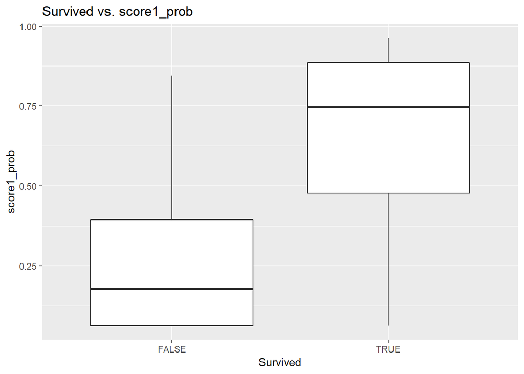

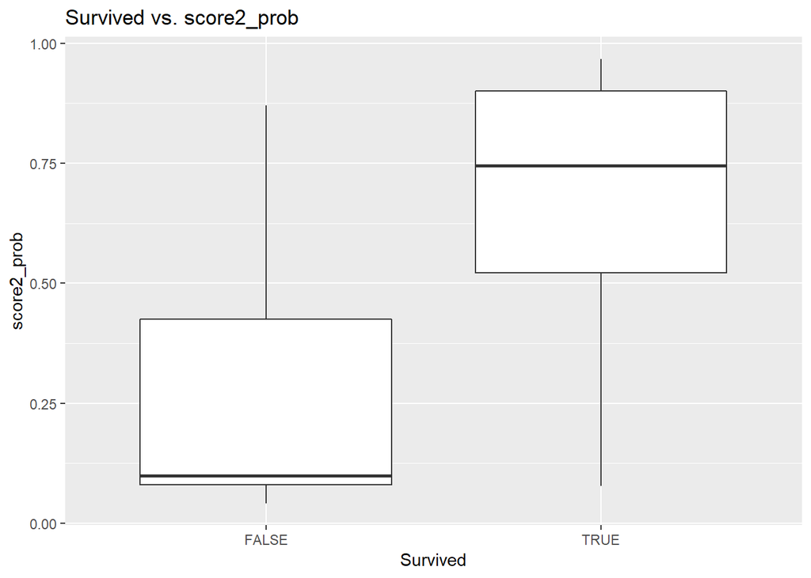

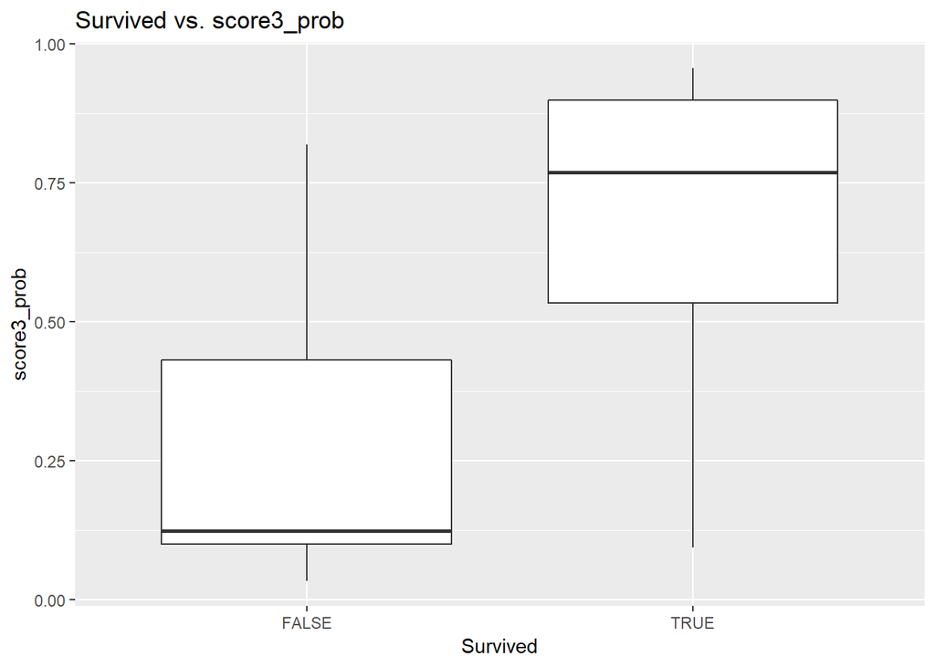

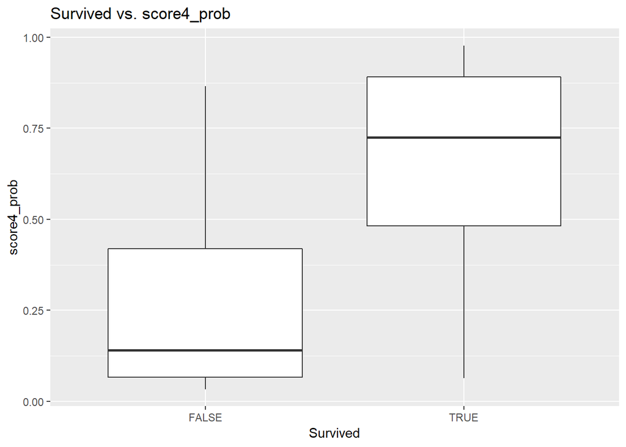

```r
#boxplots for scores
score_cols <- c("score1_prob","score2_prob","score3_prob","score4_prob")

score_cols %>% walk(gg_boxplot, df_val_norm)
```

View how the transformed scores are classified using dotplots.

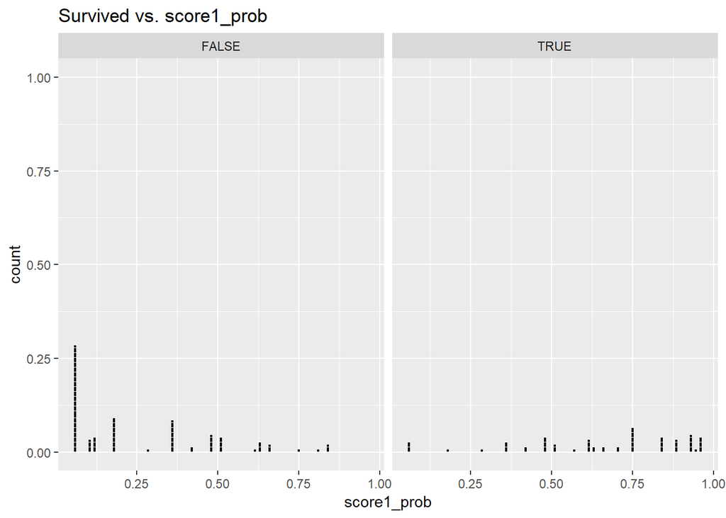

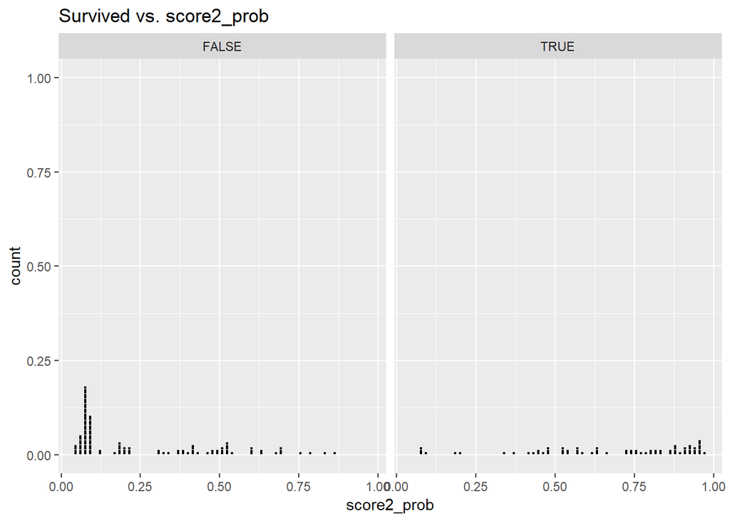

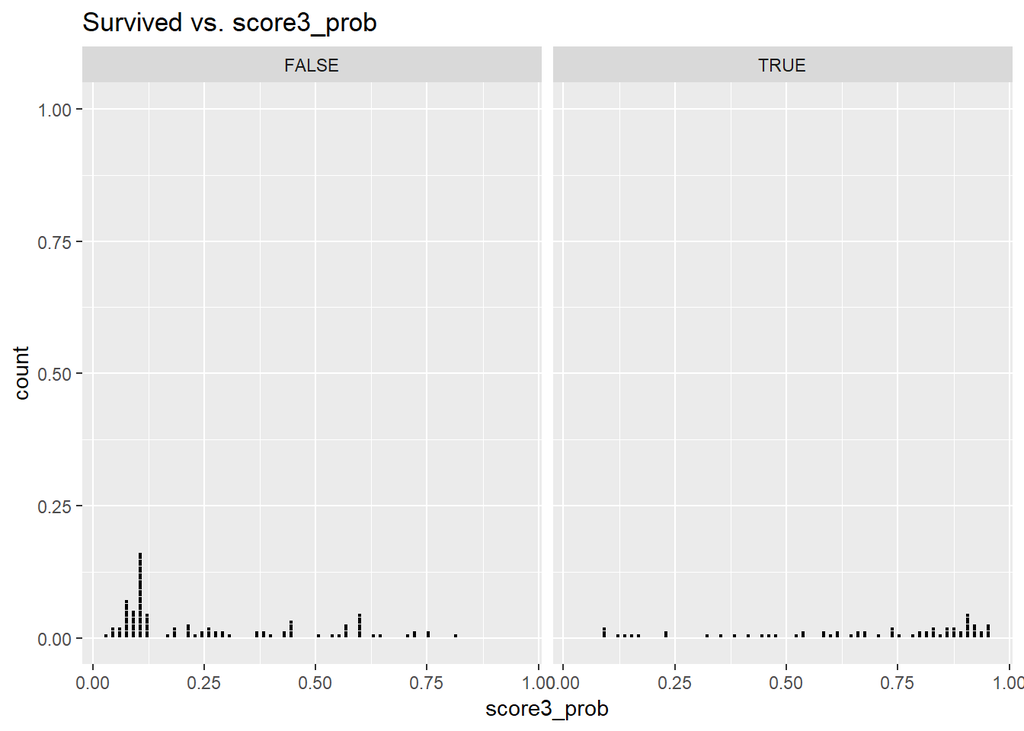

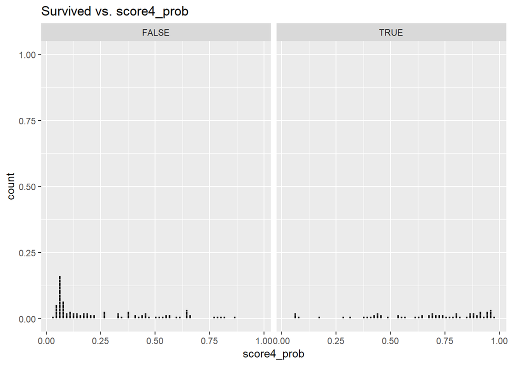

```r
# dotplots for scores
gg_dotplot <- function(x_col, data, bins = 60){
  if(is.numeric(data[[x_col]])){
    binwidth <- (max(data[,x_col]) - min(data[,x_col])) / bins
    plt <- ggplot(data, aes_string(x_col)) +
      geom_dotplot(dotsize = 0.5, method = "histodot", binwidth = binwidth) +
      facet_wrap(~Survived)+
      labs(title=str_c("Survived vs. ", x_col))

    plt %>% print()
  }
}

score_cols %>% walk(gg_dotplot, df_val_norm)
```

Create functions to find optimal classification thresholds for the models.

```r
#threshold functions
threshs = seq(0.35, 0.70, by=0.05)

test_threshold1 <- function(thresh){
  df_val_norm <- df_val_norm %>% mutate(score_pred1 = if_else(score1_prob > thresh, TRUE, FALSE) %>% as.factor())
  cat('For mod1 threshold of ', thresh, ' performance is: \n')
  cm <- confusionMatrix(data=df_val_norm$score_pred1, reference = (df_val_norm$Survived %>% as.factor()), mode = "prec_recall", positive="TRUE")
  print((cm$overall[c('Accuracy','Kappa')]))
  cat('\n')
  print(cm$byClass[c('Specificity','Sensitivity','Balanced Accuracy','F1')])
  cat('\n')
}

test_threshold2 <- function(thresh){
  df_val_norm <- df_val_norm %>% mutate(score_pred2 = if_else(score2_prob > thresh, TRUE, FALSE) %>% as.factor())
  cat('For mod2 threshold of ', thresh, ' performance is: \n')
  cm <- confusionMatrix(data=df_val_norm$score_pred2, reference = (df_val_norm$Survived %>% as.factor()), mode = "prec_recall", positive="TRUE")
  print((cm$overall[c('Accuracy','Kappa')]))
  cat('\n')
  print(cm$byClass[c('Specificity','Sensitivity','Balanced Accuracy','F1')])
  cat('\n')
}

test_threshold3 <- function(thresh){
  df_val_norm <- df_val_norm %>% mutate(score_pred3 = if_else(score3_prob > thresh, TRUE, FALSE) %>% as.factor())
  cat('For mod3 threshold of ', thresh, ' performance is: \n')
  cm <- confusionMatrix(data=df_val_norm$score_pred3, reference = (df_val_norm$Survived %>% as.factor()), mode = "prec_recall", positive="TRUE")
  print((cm$overall[c('Accuracy','Kappa')]))
  cat('\n')
  print(cm$byClass[c('Specificity','Sensitivity','Balanced Accuracy','F1')])
  cat('\n')
}


test_threshold4 <- function(thresh){
  df_val_norm <- df_val_norm %>% mutate(score_pred4 = if_else(score4_prob > thresh, TRUE, FALSE) %>% as.factor())
  cat('For mod4 threshold of ', thresh, ' performance is: \n')
  cm <- confusionMatrix(data=df_val_norm$score_pred4, reference = (df_val_norm$Survived %>% as.factor()), mode = "prec_recall", positive="TRUE")
  print((cm$overall[c('Accuracy','Kappa')]))
  cat('\n')
  print(cm$byClass[c('Specificity','Sensitivity','Balanced Accuracy','F1')])
  cat('\n')
}
```

mod1 performs best at 0.55 with an accuracy of 0.8100559.

mod2 performs best at 0.55 and 0.70 with an accuracy of 0.8100559.

mod3 performs best at 0.60 and 0.65 with an accuracy of 0.8268156.

mod4 performs best at 0.65 with an accuracy of 0.8100559.

```r
threshs %>% walk(test_threshold1)
```

```
## For mod1 threshold of  0.35  performance is:
##  Accuracy     Kappa
## 0.7374302 0.4932233
##
##       Specificity       Sensitivity Balanced Accuracy                F1
##         0.6306306         0.9117647         0.7711977         0.7251462
##
## For mod1 threshold of  0.4  performance is:
##  Accuracy     Kappa
## 0.7877095 0.5713926
##
##       Specificity       Sensitivity Balanced Accuracy                F1
##         0.7477477         0.8529412         0.8003445         0.7532468
##
## For mod1 threshold of  0.45  performance is:
##  Accuracy     Kappa
## 0.7877095 0.5666964
##
##       Specificity       Sensitivity Balanced Accuracy                F1
##         0.7657658         0.8235294         0.7946476         0.7466667
##
## For mod1 threshold of  0.5  performance is:
##  Accuracy     Kappa
## 0.7932961 0.5625206
##
##       Specificity       Sensitivity Balanced Accuracy                F1
##         0.8288288         0.7352941         0.7820615         0.7299270
##
## For mod1 threshold of  0.55  performance is:
##  Accuracy     Kappa
## 0.8100559 0.5874458
##
##       Specificity       Sensitivity Balanced Accuracy                F1
##         0.8828829         0.6911765         0.7870297         0.7343750
##
## For mod1 threshold of  0.6  performance is:
##  Accuracy     Kappa
## 0.8044693 0.5740703
##
##       Specificity       Sensitivity Balanced Accuracy                F1
##         0.8828829         0.6764706         0.7796767         0.7244094
##
## For mod1 threshold of  0.65  performance is:
##  Accuracy     Kappa
## 0.7932961 0.5333615
##
##       Specificity       Sensitivity Balanced Accuracy                F1
##         0.9279279         0.5735294         0.7507287         0.6782609
##
## For mod1 threshold of  0.7  performance is:
##  Accuracy     Kappa
## 0.7988827 0.5389898
##
##       Specificity       Sensitivity Balanced Accuracy                F1
##         0.9549550         0.5441176         0.7495363         0.6727273
```

```r
threshs %>% walk(test_threshold2)
```

```
## For mod2 threshold of  0.35  performance is:
##  Accuracy     Kappa
## 0.7541899 0.5193458
##
##       Specificity       Sensitivity Balanced Accuracy                F1
##         0.6666667         0.8970588         0.7818627         0.7349398
##
## For mod2 threshold of  0.4  performance is:
##  Accuracy     Kappa
## 0.7765363 0.5560516
##
##       Specificity       Sensitivity Balanced Accuracy                F1
##         0.7117117         0.8823529         0.7970323         0.7500000
##
## For mod2 threshold of  0.45  performance is:
##  Accuracy     Kappa
## 0.7821229 0.5565085
##
##       Specificity       Sensitivity Balanced Accuracy                F1
##         0.7567568         0.8235294         0.7901431         0.7417219
##
## For mod2 threshold of  0.5  performance is:
##  Accuracy     Kappa
## 0.7877095 0.5569884
##
##       Specificity       Sensitivity Balanced Accuracy                F1
##         0.8018018         0.7647059         0.7832538         0.7323944
##
## For mod2 threshold of  0.55  performance is:
##  Accuracy     Kappa
## 0.8100559 0.5874458
##
##       Specificity       Sensitivity Balanced Accuracy                F1
##         0.8828829         0.6911765         0.7870297         0.7343750
##
## For mod2 threshold of  0.6  performance is:
##  Accuracy     Kappa
## 0.7932961 0.5444039
##
##       Specificity       Sensitivity Balanced Accuracy                F1
##         0.8918919         0.6323529         0.7621224         0.6991870
##
## For mod2 threshold of  0.65  performance is:
##  Accuracy     Kappa
## 0.7932961 0.5333615
##
##       Specificity       Sensitivity Balanced Accuracy                F1
##         0.9279279         0.5735294         0.7507287         0.6782609
##
## For mod2 threshold of  0.7  performance is:
##  Accuracy     Kappa
## 0.8100559 0.5646015
##
##       Specificity       Sensitivity Balanced Accuracy                F1
##         0.9639640         0.5588235         0.7613937         0.6909091
```

```r
threshs %>% walk(test_threshold3)
```

```
## For mod3 threshold of  0.35  performance is:
##  Accuracy     Kappa
## 0.7541899 0.5116567
##
##       Specificity       Sensitivity Balanced Accuracy                F1
##         0.6936937         0.8529412         0.7733174         0.7250000
##
## For mod3 threshold of  0.4  performance is:
##  Accuracy     Kappa
## 0.7709497 0.5362987
##
##       Specificity       Sensitivity Balanced Accuracy                F1
##         0.7387387         0.8235294         0.7811341         0.7320261
##
## For mod3 threshold of  0.45  performance is:
##  Accuracy     Kappa
## 0.7932961 0.5722405
##
##       Specificity       Sensitivity Balanced Accuracy                F1
##         0.7927928         0.7941176         0.7934552         0.7448276
##
## For mod3 threshold of  0.5  performance is:
##  Accuracy     Kappa
## 0.7877095 0.5569884
##
##       Specificity       Sensitivity Balanced Accuracy                F1
##         0.8018018         0.7647059         0.7832538         0.7323944
##
## For mod3 threshold of  0.55  performance is:
##  Accuracy     Kappa
## 0.7821229 0.5388731
##
##       Specificity       Sensitivity Balanced Accuracy                F1
##         0.8198198         0.7205882         0.7702040         0.7153285
##
## For mod3 threshold of  0.6  performance is:
##  Accuracy     Kappa
## 0.8268156 0.6182844
##
##       Specificity       Sensitivity Balanced Accuracy                F1
##         0.9189189         0.6764706         0.7976948         0.7479675
##
## For mod3 threshold of  0.65  performance is:
##  Accuracy     Kappa
## 0.8268156 0.6113874
##
##       Specificity       Sensitivity Balanced Accuracy                F1
##         0.9459459         0.6323529         0.7891494         0.7350427
##
## For mod3 threshold of  0.7  performance is:
##  Accuracy     Kappa
## 0.8044693 0.5558942
##
##       Specificity       Sensitivity Balanced Accuracy                F1
##         0.9459459         0.5735294         0.7597377         0.6902655
```

```r
threshs %>% walk(test_threshold4)
```

```
## For mod4 threshold of  0.35  performance is:
##  Accuracy     Kappa
## 0.7709497 0.5485637
##
##       Specificity       Sensitivity Balanced Accuracy                F1
##         0.6936937         0.8970588         0.7953763         0.7484663
##
## For mod4 threshold of  0.4  performance is:
##  Accuracy     Kappa
## 0.7821229 0.5636602
##
##       Specificity       Sensitivity Balanced Accuracy                F1
##         0.7297297         0.8676471         0.7986884         0.7515924
##
## For mod4 threshold of  0.45  performance is:
##  Accuracy     Kappa
## 0.7877095 0.5594560
##
##       Specificity       Sensitivity Balanced Accuracy                F1
##         0.7927928         0.7794118         0.7861023         0.7361111
##
## For mod4 threshold of  0.5  performance is:
##  Accuracy     Kappa
## 0.7821229 0.5414778
##
##       Specificity       Sensitivity Balanced Accuracy                F1
##         0.8108108         0.7352941         0.7730525         0.7194245
##
## For mod4 threshold of  0.55  performance is:
##  Accuracy     Kappa
## 0.7877095 0.5468354
##
##       Specificity       Sensitivity Balanced Accuracy                F1
##         0.8378378         0.7058824         0.7718601         0.7164179
##
## For mod4 threshold of  0.6  performance is:
##  Accuracy     Kappa
## 0.8044693 0.5740703
##
##       Specificity       Sensitivity Balanced Accuracy                F1
##         0.8828829         0.6764706         0.7796767         0.7244094
##
## For mod4 threshold of  0.65  performance is:
##  Accuracy     Kappa
## 0.8100559 0.5775958
##
##       Specificity       Sensitivity Balanced Accuracy                F1
##         0.9189189         0.6323529         0.7756359         0.7166667
##
## For mod4 threshold of  0.7  performance is:
##  Accuracy     Kappa
## 0.7988827 0.5389898
##
##       Specificity       Sensitivity Balanced Accuracy                F1
##         0.9549550         0.5441176         0.7495363         0.6727273
```

Perform a second pass to find the optimal threshold for each model.

mod1 performs best at 0.54.

mod2 performs best at 0.70 and 0.55.

mod3 performs best at 0.61.

mod4 performs best at 0.67.

mod3 has the highest accuracy at 83.24%. This will be the final glm model chosen.

```r
#find more specific threshold for mod1
threshs = seq(0.50, 0.60, by=0.01)

threshs %>% walk(test_threshold1)
```

```
## For mod1 threshold of  0.5  performance is:
##  Accuracy     Kappa
## 0.7932961 0.5625206
##
##       Specificity       Sensitivity Balanced Accuracy                F1
##         0.8288288         0.7352941         0.7820615         0.7299270
##
## For mod1 threshold of  0.51  performance is:
##  Accuracy     Kappa
## 0.8100559 0.5874458
##
##       Specificity       Sensitivity Balanced Accuracy                F1
##         0.8828829         0.6911765         0.7870297         0.7343750
##
## For mod1 threshold of  0.52  performance is:
##  Accuracy     Kappa
## 0.8100559 0.5874458
##
##       Specificity       Sensitivity Balanced Accuracy                F1
##         0.8828829         0.6911765         0.7870297         0.7343750
##
## For mod1 threshold of  0.53  performance is:
##  Accuracy     Kappa
## 0.8100559 0.5874458
##
##       Specificity       Sensitivity Balanced Accuracy                F1
##         0.8828829         0.6911765         0.7870297         0.7343750
##
## For mod1 threshold of  0.54  performance is:
##  Accuracy     Kappa
## 0.8100559 0.5874458
##
##       Specificity       Sensitivity Balanced Accuracy                F1
##         0.8828829         0.6911765         0.7870297         0.7343750
##
## For mod1 threshold of  0.55  performance is:
##  Accuracy     Kappa
## 0.8100559 0.5874458
##
##       Specificity       Sensitivity Balanced Accuracy                F1
```

[output cut: 21 more lines]

```
##         0.8828829         0.6764706         0.7796767         0.7244094
##
## For mod1 threshold of  0.59  performance is:
##  Accuracy     Kappa
## 0.8044693 0.5740703
##
##       Specificity       Sensitivity Balanced Accuracy                F1
##         0.8828829         0.6764706         0.7796767         0.7244094
##
## For mod1 threshold of  0.6  performance is:
##  Accuracy     Kappa
## 0.8044693 0.5740703
##
##       Specificity       Sensitivity Balanced Accuracy                F1
##         0.8828829         0.6764706         0.7796767         0.7244094
```

```r
#find more specific threshold for mod2
threshs = seq(0.55, 0.70, by=0.01)

threshs %>% walk(test_threshold2)
```

```
## For mod2 threshold of  0.55  performance is:
##  Accuracy     Kappa
## 0.8100559 0.5874458
##
##       Specificity       Sensitivity Balanced Accuracy                F1
##         0.8828829         0.6911765         0.7870297         0.7343750
##
## For mod2 threshold of  0.56  performance is:
##  Accuracy     Kappa
## 0.8100559 0.5874458
##
##       Specificity       Sensitivity Balanced Accuracy                F1
##         0.8828829         0.6911765         0.7870297         0.7343750
##
## For mod2 threshold of  0.57  performance is:
##  Accuracy     Kappa
## 0.7988827 0.5606164
##
##       Specificity       Sensitivity Balanced Accuracy                F1
##         0.8828829         0.6617647         0.7723238         0.7142857
##
## For mod2 threshold of  0.58  performance is:
##  Accuracy     Kappa
## 0.7932961 0.5470834
##
##       Specificity       Sensitivity Balanced Accuracy                F1
##         0.8828829         0.6470588         0.7649709         0.7040000
##
## For mod2 threshold of  0.59  performance is:
##  Accuracy     Kappa
## 0.7877095 0.5334705
##
##       Specificity       Sensitivity Balanced Accuracy                F1
##         0.8828829         0.6323529         0.7576179         0.6935484
##
## For mod2 threshold of  0.6  performance is:
##  Accuracy     Kappa
## 0.7932961 0.5444039
##
##       Specificity       Sensitivity Balanced Accuracy                F1
```

[output cut: 56 more lines]

```
##         0.9279279         0.5588235         0.7433757         0.6666667
##
## For mod2 threshold of  0.69  performance is:
##  Accuracy     Kappa
## 0.7988827 0.5418089
##
##       Specificity       Sensitivity Balanced Accuracy                F1
##         0.9459459         0.5588235         0.7523847         0.6785714
##
## For mod2 threshold of  0.7  performance is:
##  Accuracy     Kappa
## 0.8100559 0.5646015
##
##       Specificity       Sensitivity Balanced Accuracy                F1
##         0.9639640         0.5588235         0.7613937         0.6909091
```

```r
#find more specific threshold for mod3
threshs = seq(0.60, 0.65, by=0.01)

threshs %>% walk(test_threshold3)
```

```
## For mod3 threshold of  0.6  performance is:
##  Accuracy     Kappa
## 0.8268156 0.6182844
##
##       Specificity       Sensitivity Balanced Accuracy                F1
##         0.9189189         0.6764706         0.7976948         0.7479675
##
## For mod3 threshold of  0.61  performance is:
##  Accuracy     Kappa
## 0.8324022 0.6295019
##
##       Specificity       Sensitivity Balanced Accuracy                F1
##         0.9279279         0.6764706         0.8021993         0.7540984
##
## For mod3 threshold of  0.62  performance is:
##  Accuracy     Kappa
## 0.8212291 0.6024431
##
##       Specificity       Sensitivity Balanced Accuracy                F1
##         0.9279279         0.6470588         0.7874934         0.7333333
##
## For mod3 threshold of  0.63  performance is:
##  Accuracy     Kappa
## 0.8268156 0.6137139
##
##       Specificity       Sensitivity Balanced Accuracy                F1
##         0.9369369         0.6470588         0.7919979         0.7394958
##
## For mod3 threshold of  0.64  performance is:
##  Accuracy     Kappa
## 0.8324022 0.6250524
##
##       Specificity       Sensitivity Balanced Accuracy                F1
##         0.9459459         0.6470588         0.7965024         0.7457627
##
## For mod3 threshold of  0.65  performance is:
##  Accuracy     Kappa
## 0.8268156 0.6113874
##
##       Specificity       Sensitivity Balanced Accuracy                F1
##         0.9459459         0.6323529         0.7891494         0.7350427
```

```r
#find more specific threshold for mod4
threshs = seq(0.60, 0.70, by=0.01)

threshs %>% walk(test_threshold4)
```

```
## For mod4 threshold of  0.6  performance is:
##  Accuracy     Kappa
## 0.8044693 0.5740703
##
##       Specificity       Sensitivity Balanced Accuracy                F1
##         0.8828829         0.6764706         0.7796767         0.7244094
##
## For mod4 threshold of  0.61  performance is:
##  Accuracy     Kappa
## 0.8044693 0.5740703
##
##       Specificity       Sensitivity Balanced Accuracy                F1
##         0.8828829         0.6764706         0.7796767         0.7244094
##
## For mod4 threshold of  0.62  performance is:
##  Accuracy     Kappa
## 0.8100559 0.5850266
##
##       Specificity       Sensitivity Balanced Accuracy                F1
##         0.8918919         0.6764706         0.7841812         0.7301587
##
## For mod4 threshold of  0.63  performance is:
##  Accuracy     Kappa
## 0.8044693 0.5715653
##
##       Specificity       Sensitivity Balanced Accuracy                F1
##         0.8918919         0.6617647         0.7768283         0.7200000
##
## For mod4 threshold of  0.64  performance is:
##  Accuracy     Kappa
## 0.8044693 0.5690307
##
##       Specificity       Sensitivity Balanced Accuracy                F1
##         0.9009009         0.6470588         0.7739799         0.7154472
##
## For mod4 threshold of  0.65  performance is:
##  Accuracy     Kappa
## 0.8100559 0.5775958
##
##       Specificity       Sensitivity Balanced Accuracy                F1
```

[output cut: 21 more lines]

```
##         0.9549550         0.6029412         0.7789481         0.7192982
##
## For mod4 threshold of  0.69  performance is:
##  Accuracy     Kappa
## 0.8044693 0.5531702
##
##       Specificity       Sensitivity Balanced Accuracy                F1
##         0.9549550         0.5588235         0.7568892         0.6846847
##
## For mod4 threshold of  0.7  performance is:
##  Accuracy     Kappa
## 0.7988827 0.5389898
##
##       Specificity       Sensitivity Balanced Accuracy                F1
##         0.9549550         0.5441176         0.7495363         0.6727273
```

## 7.2 Random Forest

Create a Random Forest model to see if results can be improved.

```r
set.seed(123)
mod5 <- randomForest(as.factor(Survived) ~ Pclass+Sex+Age+SibSp+Fare+Embarked+Title+Group+Family+CabinLtr,
                     ntree=500, mtry=7, data=df_train_norm, importance=TRUE)
mod5
```

```
##
## Call:
##  randomForest(formula = as.factor(Survived) ~ Pclass + Sex + Age +      SibSp + Fare + Embarked + Title + Group + Family + CabinLtr,      data = df_train_norm, ntree = 500, mtry = 7, importance = TRUE)
##                Type of random forest: classification
##                      Number of trees: 500
## No. of variables tried at each split: 7
##
##         OOB estimate of  error rate: 17.6%
## Confusion matrix:
##       FALSE TRUE class.error
## FALSE   387   54   0.1224490
## TRUE     72  203   0.2618182
```

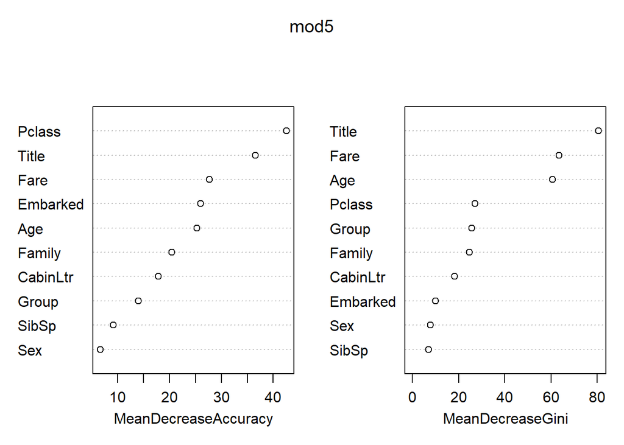

```r
#visualize feature importance
varImpPlot(mod5)
```

```r
# Use For loop to identify the right mtry for mod5
a=c()
i=5
for (i in 3:8) {
  set.seed(123)
  mod5 <- randomForest(as.factor(Survived) ~ Pclass+Sex+Age+Fare+Embarked+Title+Family+CabinLtr+Group,
                       data=df_train_norm, ntree = 500, mtry = i, importance = TRUE)
  df_train_norm$score_pred5 <- predict(mod5, df_train_norm, type = "class")
  a[i-2] = mean(df_train_norm$score_pred5 == df_train_norm$Survived)
}

a
```

```
## [1] 0.9371508 0.9525140 0.9734637 0.9874302 0.9888268 0.9888268
```

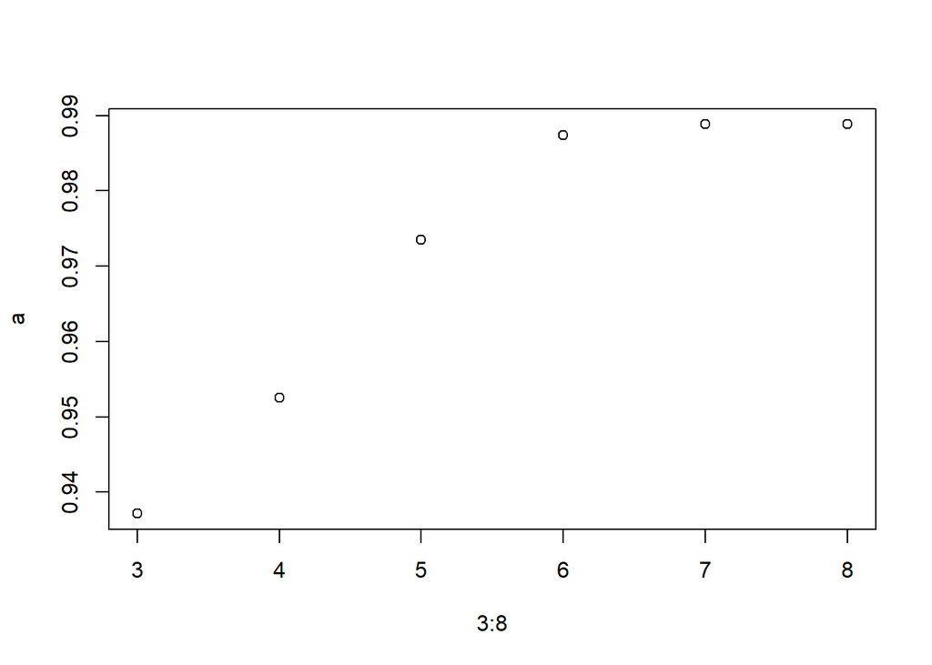

```r
plot(3:8,a)
```

Add predictions into dataframe.

mod5 has an accuracy of 98.88% with training data. Using validation data it has an accuracy of 79.89%. The model is overfit but the accuracy still isn’t bad.

```r
#score/predict results for random forest models
df_train_norm$score_pred5 <- predict(mod5, df_train_norm, type="class")

mean(df_train_norm$score_pred5 == df_train_norm$Survived)
```

```
## [1] 0.9888268
```

```r
table(df_train_norm$score_pred5,df_train_norm$Survived)
```

```
##
##         FALSE TRUE
##   FALSE   439    6
##   TRUE      2  269
```

```r
df_val_norm$score_pred5 <- predict(mod5, newdata = df_val_norm)

mean(df_val_norm$score_pred5 == df_val_norm$Survived)
```

```
## [1] 0.7988827
```

```r
table(df_val_norm$score_pred5, df_val_norm$Survived)
```

```
##
##         FALSE TRUE
##   FALSE    89   14
##   TRUE     22   54
```

## 7.3 K-Nearest Neighbors

Run a KNN model to see if we can improve results. First, prepare the data to work with a KNN model better.

```r
# set up new dataframe to turn factors into binary dummy variables for knn model
df_num_norm <- df_norm %>% mutate_if(is.ordered, as.character)
df_num_norm <- df_num_norm %>% mutate_if(is.character, as.factor)
df_num_norm <- df_num_norm %>% mutate(Child = as.factor(Child))

df_num_norm <- fastDummies::dummy_cols(df_num_norm)

df_num_norm <- df_num_norm %>% select(1:2,Age,Fare,15:81)

df_num_norm %>% glimpse()
```

```
## Observations: 1,316
## Variables: 71
## $ PassengerId          <int> 1, 2, 3, 4, 5, 6, 7, 8, 9, 10, 11, 12, 13...
## $ Survived             <lgl> FALSE, TRUE, TRUE, TRUE, FALSE, FALSE, FA...
## $ Age                  <dbl> -0.55963667, 0.66141600, -0.25437350, 0.4...
## $ Fare                 <dbl> -0.50169283, 0.73844524, -0.48862006, 0.3...
## $ Pclass_3             <int> 1, 0, 1, 0, 1, 1, 0, 1, 1, 0, 1, 0, 1, 1,...
## $ Pclass_1             <int> 0, 1, 0, 1, 0, 0, 1, 0, 0, 0, 0, 1, 0, 0,...
## $ Pclass_2             <int> 0, 0, 0, 0, 0, 0, 0, 0, 0, 1, 0, 0, 0, 0,...
## $ Sex_male             <int> 1, 0, 0, 0, 1, 1, 1, 1, 0, 0, 0, 0, 1, 1,...
## $ Sex_female           <int> 0, 1, 1, 1, 0, 0, 0, 0, 1, 1, 1, 1, 0, 0,...
## $ SibSp_1              <int> 1, 1, 0, 1, 0, 0, 0, 0, 0, 1, 1, 0, 0, 1,...
## $ SibSp_0              <int> 0, 0, 1, 0, 1, 1, 1, 0, 1, 0, 0, 1, 1, 0,...
## $ SibSp_3              <int> 0, 0, 0, 0, 0, 0, 0, 1, 0, 0, 0, 0, 0, 0,...
## $ SibSp_4              <int> 0, 0, 0, 0, 0, 0, 0, 0, 0, 0, 0, 0, 0, 0,...
```

[output cut: 58 more lines]

```r
#create test, train, and validation set
df_num_test_norm <- df_num_norm %>% filter(is.na(Survived))

set.seed(123)
df_num_train_norm <- df_num_norm %>% filter(!is.na(Survived)) %>% sample_frac(0.8)
df_num_val_norm <- df_num_norm %>% filter(!is.na(Survived)) %>% setdiff(df_num_train_norm)
```

Create the KNN model.

The features from mod1 appear to produce the highest accuracy in the KNN model.

```r
#create function to find accuracy
accuracy <- function(x){
  num <- x %>% filter(x$Survived == x$score) %>% nrow()
  (num/nrow(x)) * 100
}

#use names function to get variable numbers easier
df_num_train_norm %>% names()
```

```
##  [1] "PassengerId"        "Survived"           "Age"
##  [4] "Fare"               "Pclass_3"           "Pclass_1"
##  [7] "Pclass_2"           "Sex_male"           "Sex_female"
## [10] "SibSp_1"            "SibSp_0"            "SibSp_3"
## [13] "SibSp_4"            "SibSp_2"            "SibSp_5"
## [16] "SibSp_8"            "Embarked_S"         "Embarked_C"
## [19] "Embarked_Q"         "Embarked_NA"        "Title_Mr"
## [22] "Title_Mrs"          "Title_Miss"         "Title_Master"
## [25] "Title_Don"          "Title_Rev"          "Title_Dr"
## [28] "Title_Mme"          "Title_Ms"           "Title_Major"
## [31] "Title_Lady"         "Title_Sir"          "Title_Mlle"
## [34] "Title_Col"          "Title_Capt"         "Title_the Countess"
## [37] "Title_Jonkheer"     "Title_Dona"         "Group_Officer"
## [40] "Group_Mrs"          "Group_Miss"         "Group_Master"
## [43] "Group_Royalty"      "Family_1"           "Family_0"
## [46] "Family_4"           "Family_2"           "Family_6"
## [49] "Family_5"           "Family_3"           "Family_7"
## [52] "Family_10"          "ParCh_0"            "ParCh_1"
## [55] "ParCh_2"            "ParCh_5"            "ParCh_3"
## [58] "ParCh_4"            "ParCh_6"            "ParCh_9"
## [61] "Child_FALSE"        "Child_TRUE"         "CabinLtr_NA"
## [64] "CabinLtr_C"         "CabinLtr_E"         "CabinLtr_G"
## [67] "CabinLtr_D"         "CabinLtr_A"         "CabinLtr_B"
## [70] "CabinLtr_F"         "CabinLtr_T"
```

```r
#create function to find best value for k
ks = seq(1,29,by=2)
for(k in ks) {
  mod6 <- knn(train=df_num_train_norm[c(5:7,17:20,39:43)], test=df_num_val_norm[c(5:7,17:20,39:43)], cl=df_num_train_norm$Survived, k=k)
  df_num_train_norm$score <- mod6
  cat(c("k=",k,":",accuracy(df_num_train_norm),"\n"))
}
```

```
## k= 1 : 54.608938547486
## k= 3 : 54.0502793296089
## k= 5 : 52.9329608938548
## k= 7 : 55.1675977653631
## k= 9 : 55.4469273743017
## k= 11 : 55.7262569832402
## k= 13 : 55.4469273743017
## k= 15 : 56.0055865921788
## k= 17 : 55.7262569832402
## k= 19 : 55.1675977653631
## k= 21 : 56.8435754189944
## k= 23 : 56.2849162011173
## k= 25 : 57.4022346368715
## k= 27 : 58.2402234636871
## k= 29 : 58.2402234636871
```

```r
#create knn model based on highest value from above
mod6 <- knn(train=df_num_train_norm[c(5:7,17:20,39:43)], test=df_num_val_norm[c(5:7,17:20,39:43)], cl=df_num_train_norm$Survived, k=27)
```

Add predictions into dataframe.

mod6 has an accuracy of 58.24%. This is very low so the model will not be used.

```r
#add predictions to data frame
df_num_train_norm$score <- mod6

#create confusion matrix
CrossTable(x=df_num_train_norm$Survived, y=df_num_train_norm$score)
```

```
##
##
##    Cell Contents
## |-------------------------|
## |                       N |
## | Chi-square contribution |
## |           N / Row Total |
## |           N / Col Total |
## |         N / Table Total |
## |-------------------------|
##
##
## Total Observations in Table:  716
##
##
##                            | df_num_train_norm$score
## df_num_train_norm$Survived |     FALSE |      TRUE | Row Total |
## ---------------------------|-----------|-----------|-----------|
##                      FALSE |       359 |        82 |       441 |
##                            |     0.050 |     0.207 |           |
##                            |     0.814 |     0.186 |     0.616 |
##                            |     0.623 |     0.586 |           |
##                            |     0.501 |     0.115 |           |
## ---------------------------|-----------|-----------|-----------|
##                       TRUE |       217 |        58 |       275 |
##                            |     0.081 |     0.333 |           |
##                            |     0.789 |     0.211 |     0.384 |
##                            |     0.377 |     0.414 |           |
##                            |     0.303 |     0.081 |           |
## ---------------------------|-----------|-----------|-----------|
##               Column Total |       576 |       140 |       716 |
##                            |     0.804 |     0.196 |           |
## ---------------------------|-----------|-----------|-----------|
##
##
```

```r
accuracy(df_num_train_norm)
```

```
## [1] 58.24022
```

# 8 Model Performance

Compare mod3 and mod5.

mod3 has a higher accuracy of 83.24% vs. mod5 at 79.89%.

mod3 will be the final model used to predict survival.

```r
#add final thresholds for mod3
df_val_norm <- df_val_norm %>% mutate(score_pred3 = if_else(score3_prob > 0.61, TRUE, FALSE) %>% as.factor())

#confusion matrices
confusionMatrix(data=df_val_norm$score_pred3, reference = (df_val_norm$Survived %>% as.factor()), mode = "prec_recall", positive="TRUE")
```

```
## Confusion Matrix and Statistics
##
##           Reference
## Prediction FALSE TRUE
##      FALSE   103   22
##      TRUE      8   46
##
##                Accuracy : 0.8324
##                  95% CI : (0.7695, 0.884)
##     No Information Rate : 0.6201
##     P-Value [Acc > NIR] : 4.773e-10
##
##                   Kappa : 0.6295
##
##  Mcnemar's Test P-Value : 0.01762
##
##               Precision : 0.8519
##                  Recall : 0.6765
##                      F1 : 0.7541
##              Prevalence : 0.3799
##          Detection Rate : 0.2570
##    Detection Prevalence : 0.3017
##       Balanced Accuracy : 0.8022
##
##        'Positive' Class : TRUE
##
```

```r
confusionMatrix(data=df_val_norm$score_pred5, reference = (df_val_norm$Survived %>% as.factor()), mode = "prec_recall", positive="TRUE")
```

```
## Confusion Matrix and Statistics
##
##           Reference
## Prediction FALSE TRUE
##      FALSE    89   14
##      TRUE     22   54
##
##                Accuracy : 0.7989
##                  95% CI : (0.7326, 0.855)
##     No Information Rate : 0.6201
##     P-Value [Acc > NIR] : 2.01e-07
##
##                   Kappa : 0.5826
##
##  Mcnemar's Test P-Value : 0.2433
##
##               Precision : 0.7105
##                  Recall : 0.7941
##                      F1 : 0.7500
##              Prevalence : 0.3799
##          Detection Rate : 0.3017
##    Detection Prevalence : 0.4246
##       Balanced Accuracy : 0.7980
##
##        'Positive' Class : TRUE
##
```

View ROC curve and AUC as another check for model performance.

The ROC curve looks pretty good and the AUC is 87.62%.

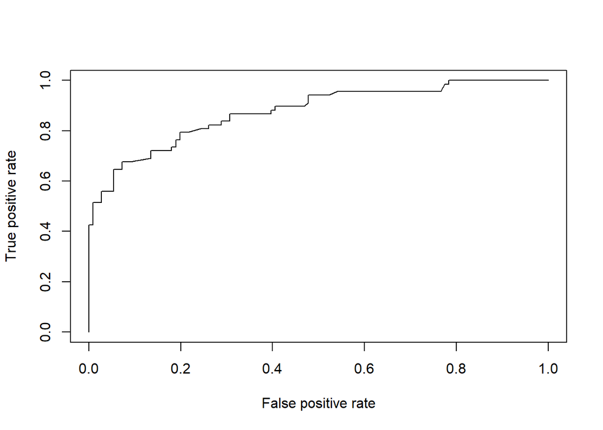

```r
#ROC curve and AUC
p <- predict(mod3, newdata=subset(df_val_norm,select=(-Survived)), type="response")
pr <- prediction(p, df_val_norm$Survived)
prf <- performance(pr, measure = "tpr", x.measure = "fpr")
plot(prf)
```

```r
auc <- performance(pr, measure = "auc")
auc <- auc@y.values[[1]]
auc
```

```
## [1] 0.8761924
```

Finally, lets predict results with the original df_test data frame.

```r
#apply model
df_test_norm$score <- predict(mod3, newdata = df_test_norm)

df_final <- df_test_norm %>% mutate(score_prob = exp(score)/(1 + exp(score)),
                                    Survived = if_else(score_prob > 0.61, TRUE, FALSE) %>% as.numeric(),
                                    PassengerId = as.double(PassengerId)) %>%
  select(PassengerId,Survived)

df_final <- df_final %>% distinct()
df_final %>% return()
```

```
## # A tibble: 418 x 2
##    PassengerId Survived
##          <dbl>    <dbl>
##  1         892        0
##  2         893        0
##  3         894        0
##  4         895        0
##  5         896        1
##  6         897        0
##  7         898        0
##  8         899        0
##  9         900        1
## 10         901        0
## # ... with 408 more rows
```

Export results.

```r
write_csv(df_final, path=str_c(path, "titanic_predictions-v5.csv"))
```